# Optimizing Zillow Housing Price Estimate

Hedonic Housing Model

Anushka Samant, Delfina Vildosola

2023-12-20

```r
# functions and data directory


#plotTheme FOR CHAPTER 1, 6, 7 = title_size = 16
#plotTheme FOR CHAPTER 2       = title_size = 24
#plotTheme FOR CHAPTER 3,4,5,8 = title_size = 14
plotTheme <- function(base_size = 12, title_size = 16) {
  theme(
    text = element_text( color = "black"),
    plot.title = element_text(size = title_size, colour = "black"),
    plot.subtitle = element_text(face="italic"),
    plot.caption = element_text(hjust=0),
    axis.ticks = element_blank(),
    panel.background = element_blank(),
    panel.grid.major = element_line("grey80", size = 0.1),
    panel.grid.minor = element_blank(),
    panel.border = element_rect(colour = "black", fill=NA, size=2),
    strip.background = element_rect(fill = "grey80", color = "white"),
    strip.text = element_text(size=12),
    axis.title = element_text(size=12),
    axis.text = element_text(size=10),
    plot.background = element_blank(),
    legend.background = element_blank(),
    legend.title = element_text(colour = "black", face = "italic"),
    legend.text = element_text(colour = "black", face = "italic"),
    strip.text.x = element_text(size = 14)
  )
}

#mapTheme FOR CHAPTER 1       = title_size = 16
#mapTheme FOR CHAPTER 2       = title_size = 24
#mapTheme FOR CHAPTER 3,4,5,8 = title_size = 14
mapTheme <- function(base_size = 12, title_size = 16) {
  theme(
    text = element_text( color = "black"),
    plot.title = element_text(size = title_size,colour = "black"),
    plot.subtitle=element_text(face="italic"),
    plot.caption=element_text(hjust=0),
    axis.ticks = element_blank(),
    panel.background = element_blank(),axis.title = element_blank(),
    axis.text = element_blank(),
    axis.title.x = element_blank(),
    axis.title.y = element_blank(),
    panel.grid.minor = element_blank(),
    panel.border = element_rect(colour = "black", fill=NA, size=2),
    strip.text.x = element_text(size = 14))
}

q5 <- function(variable) {as.factor(ntile(variable, 5))}

qBr <- function(df, variable, rnd) {
  if (missing(rnd)) {
    as.character(quantile(round(df[[variable]],0),
                          c(.01,.2,.4,.6,.8), na.rm=T))
  } else if (rnd == FALSE | rnd == F) {
    as.character(formatC(quantile(df[[variable]],
                                  c(.01,.2,.4,.6,.8), na.rm=T),
                         digits = 3))
  }
}

#this function converts a raster to a data frame that can be plotted
rast <- function(inRaster) {
  data.frame(
    xyFromCell(inRaster, 1:ncell(inRaster)),
    value = getValues(inRaster)) }

##this is the nearest neighbor function
nn_function <- function(measureFrom,measureTo,k) {
  measureFrom_Matrix <-
    as.matrix(measureFrom)
  measureTo_Matrix <-
    as.matrix(measureTo)
  nn <-
    get.knnx(measureTo, measureFrom, k)$nn.dist
  output <-
    as.data.frame(nn) %>%
    rownames_to_column(var = "thisPoint") %>%
    gather(points, point_distance, V1:ncol(.)) %>%
    arrange(as.numeric(thisPoint)) %>%
    group_by(thisPoint) %>%
    summarize(pointDistance = mean(point_distance)) %>%
    arrange(as.numeric(thisPoint)) %>%
    dplyr::select(-thisPoint) %>%
    pull()

  return(output)
}

# Multi-ring Buffer
multipleRingBuffer <- function(inputPolygon, maxDistance, interval)
{
  #create a list of distances that we'll iterate through to create each ring
  distances <- seq(0, maxDistance, interval)
  #we'll start with the second value in that list - the first is '0'
  distancesCounter <- 2
  #total number of rings we're going to create
  numberOfRings <- floor(maxDistance / interval)
  #a counter of number of rings
  numberOfRingsCounter <- 1
  #initialize an otuput data frame (that is not an sf)
  allRings <- data.frame()

  #while number of rings  counteris less than the specified nubmer of rings
  while (numberOfRingsCounter <= numberOfRings)
  {
    #if we're interested in a negative buffer and this is the first buffer
    #(ie. not distance = '0' in the distances list)
    if(distances[distancesCounter] < 0 & distancesCounter == 2)
    {
      #buffer the input by the first distance
      buffer1 <- st_buffer(inputPolygon, distances[distancesCounter])
      #different that buffer from the input polygon to get the first ring
      buffer1_ <- st_difference(inputPolygon, buffer1)
      #cast this sf as a polygon geometry type
      thisRing <- st_cast(buffer1_, "POLYGON")
      #take the last column which is 'geometry'
      thisRing <- as.data.frame(st_geometry(thisRing))
      #add a new field, 'distance' so we know how far the distance is for a give ring
      thisRing$distance <- distances[distancesCounter]
    }


    #otherwise, if this is the second or more ring (and a negative buffer)
    else if(distances[distancesCounter] < 0 & distancesCounter > 2)
    {
      #buffer by a specific distance
      buffer1 <- st_buffer(inputPolygon, distances[distancesCounter])
      #create the next smallest buffer
      buffer2 <- st_buffer(inputPolygon, distances[distancesCounter-1])
      #This can then be used to difference out a buffer running from 660 to 1320
      #This works because differencing 1320ft by 660ft = a buffer between 660 & 1320.
      #bc the area after 660ft in buffer2 = NA.
      thisRing <- st_difference(buffer2,buffer1)
      #cast as apolygon
      thisRing <- st_cast(thisRing, "POLYGON")
      #get the last field
      thisRing <- as.data.frame(st_geometry(thisRing))
      #create the distance field
      thisRing$distance <- distances[distancesCounter]
    }

    #Otherwise, if its a positive buffer
    else
    {
      #Create a positive buffer
      buffer1 <- st_buffer(inputPolygon, distances[distancesCounter])
      #create a positive buffer that is one distance smaller. So if its the first buffer
      #distance, buffer1_ will = 0.
      buffer1_ <- st_buffer(inputPolygon, distances[distancesCounter-1])
      #difference the two buffers
      thisRing <- st_difference(buffer1,buffer1_)
      #cast as a polygon
      thisRing <- st_cast(thisRing, "POLYGON")
      #geometry column as a data frame
      thisRing <- as.data.frame(st_geometry(thisRing))
      #add teh distance
      thisRing$distance <- distances[distancesCounter]
    }
```

```r
    #rbind this ring to the rest of the rings
    allRings <- rbind(allRings, thisRing)
    #iterate the distance counter
    distancesCounter <- distancesCounter + 1
    #iterate the number of rings counter
    numberOfRingsCounter <- numberOfRingsCounter + 1
  }

  #convert the allRings data frame to an sf data frame
  allRings <- st_as_sf(allRings)
}

# Cross-validate function from chapter 5 (left in chapter)
crossValidate <- function(dataset, id, dependentVariable, indVariables) {

  allPredictions <- data.frame()
  cvID_list <- unique(dataset[[id]])

  for (i in cvID_list) {

    thisFold <- i
    cat("This hold out fold is", thisFold, "\n")

    fold.train <- filter(dataset, dataset[[id]] != thisFold) %>% as.data.frame() %>%
      dplyr::select(id, geometry, all_of(indVariables),
                    all_of(dependentVariable))
    fold.test  <- filter(dataset, dataset[[id]] == thisFold) %>% as.data.frame() %>%
      dplyr::select(id, geometry, all_of(indVariables),
                    all_of(dependentVariable))

    form_parts <- paste0(dependentVariable, " ~ ", paste0(indVariables, collapse = "+"))
    form <- as.formula(form_parts)
    regression <- glm(form, family = "poisson",
                      data = fold.train %>%
                        dplyr::select(-geometry, -id))

    thisPrediction <-
      mutate(fold.test, Prediction = predict(regression, fold.test, type = "response"))

    allPredictions <-
      rbind(allPredictions, thisPrediction)

  }
  return(st_sf(allPredictions))
}


# Iterate Thresholds Chapter 6, 7 (left in Chapters)
iterateThresholds <- function(data, observedClass, predictedProbs, group) {
  #This function takes as its inputs, a data frame with an observed binomial class (1 or 0); a vector of predicted #probabilities; and optionally a group indicator like race. It returns accuracy plus counts and rates of confusion matrix #outcomes. It's a bit verbose because of the if (missing(group)). I don't know another way to make an optional parameter.
  observedClass <- enquo(observedClass)
  predictedProbs <- enquo(predictedProbs)
  group <- enquo(group)
  x = .01
  all_prediction <- data.frame()

  if (missing(group)) {

    while (x <= 1) {
      this_prediction <- data.frame()

      this_prediction <-
        data %>%
        mutate(predclass = ifelse(!!predictedProbs > x, 1,0)) %>%
        count(predclass, !!observedClass) %>%
        summarize(Count_TN = sum(n[predclass==0 & !!observedClass==0]),
                  Count_TP = sum(n[predclass==1 & !!observedClass==1]),
                  Count_FN = sum(n[predclass==0 & !!observedClass==1]),
                  Count_FP = sum(n[predclass==1 & !!observedClass==0]),
                  Rate_TP = Count_TP / (Count_TP + Count_FN),
                  Rate_FP = Count_FP / (Count_FP + Count_TN),
                  Rate_FN = Count_FN / (Count_FN + Count_TP),
                  Rate_TN = Count_TN / (Count_TN + Count_FP),
                  Accuracy = (Count_TP + Count_TN) /
                    (Count_TP + Count_TN + Count_FN + Count_FP)) %>%
        mutate(Threshold = round(x,2))

      all_prediction <- rbind(all_prediction,this_prediction)
      x <- x + .01
    }
    return(all_prediction)
  }
  else if (!missing(group)) {
    while (x <= 1) {
      this_prediction <- data.frame()

      this_prediction <-
        data %>%
        mutate(predclass = ifelse(!!predictedProbs > x, 1,0)) %>%
        group_by(!!group) %>%
        count(predclass, !!observedClass) %>%
        summarize(Count_TN = sum(n[predclass==0 & !!observedClass==0]),
                  Count_TP = sum(n[predclass==1 & !!observedClass==1]),
                  Count_FN = sum(n[predclass==0 & !!observedClass==1]),
                  Count_FP = sum(n[predclass==1 & !!observedClass==0]),
                  Rate_TP = Count_TP / (Count_TP + Count_FN),
                  Rate_FP = Count_FP / (Count_FP + Count_TN),
                  Rate_FN = Count_FN / (Count_FN + Count_TP),
                  Rate_TN = Count_TN / (Count_TN + Count_FP),
                  Accuracy = (Count_TP + Count_TN) /
                    (Count_TP + Count_TN + Count_FN + Count_FP)) %>%
        mutate(Threshold = round(x,2))

      all_prediction <- rbind(all_prediction,this_prediction)
      x <- x + .01
    }
    return(all_prediction)
  }
}

# Iterate Fairness Chapter 7 (left in chapter)
iterateFairness <- function(data, regression, threshold.by) {
  #create a table of all possible threshold combinations and input how many different thresholds to test.
  all.combos <- expand.grid(group1 = seq(0.1 , 1, threshold.by), group2 = seq(0.1,1 ,threshold.by))
  all_prediction <- data.frame()
  #while `counter` is less than the number of possible threshold combinations
  counter = 1
  while (counter <= nrow(all.combos)) {
    this_prediction <- data.frame()
    #choose the next i thresholds
    group1.thresh <- all.combos[counter,1]
    group2.thresh <- all.combos[counter,2]
    #create a temporary table that includes the predicted probability
    this_prediction <- data.frame(
      observed = data[["Recidivated"]],
      probs = predict(regression, data, type="response"),
      race = data[["race"]]) %>%
      mutate(predicted =
               case_when(race == "African-American" & probs >= group1.thresh  ~ "Recidivate",
                         race == "Caucasian" & probs >= group2.thresh  ~ "Recidivate",
                         TRUE ~"notRecidivate"),
             predicted = as.factor(predicted)) %>%
      #calculate fairness metrics
      group_by(race) %>%
      count(predicted,observed) %>%
      summarize(True_Negative = sum(n[predicted=="notRecidivate" & observed=="notRecidivate"]),
                True_Positive = sum(n[predicted=="Recidivate" & observed=="Recidivate"]),
                False_Negative = sum(n[predicted=="notRecidivate" & observed=="Recidivate"]),
                False_Positive = sum(n[predicted=="Recidivate" & observed=="notRecidivate"]),
                False_Positive_Rate = False_Positive / (False_Positive + True_Negative),
                False_Negative_Rate = False_Negative / (False_Negative + True_Positive),
                Accuracy = (True_Negative + True_Positive) /
                  (True_Negative + True_Positive + False_Negative + False_Positive)) %>%
      mutate(threshold = paste(group1.thresh, group2.thresh, sep=", "))
    #store this outcome on a larger table
    all_prediction <- rbind(all_prediction,this_prediction)
    #iterate
    counter <- counter + 1
  }
  #return fairness metrics for all threshold combinations
  return(all_prediction)
}
```

```r
read_and_transform <- function(path, epsg) {
  data <- st_read(path) %>%
    st_transform(epsg)
  return (data)
}

#Distance
halfmile = 5280/2
mile = 5280
sqmile = 27878400

set.seed(123)

#Visuals
options(scipen=999)
options(tigris_class = "sf")

palette9 <- c("#54bebe", "#76c8c8", "#98d1d1", "#badbdb", "#dedad2", "#e4bcad", "#df979e", "#d7658b", "#c80064")

# functions and data directory
root.dir = "https://raw.githubusercontent.com/urbanSpatial/Public-Policy-Analytics-Landing/master/DATA/"

#source("https://raw.githubusercontent.com/urbanSpatial/Public-Policy-Analytics-Landing/master/functions.r")

### Anushka
setwd("D:/OneDrive - PennO365/Semester 3/PPA/Midterm/Data")   #set a working directory
studentData <- st_read("D:/OneDrive - PennO365/Semester 3/PPA/Midterm/Data/studentData.geojson") # Read GeoJSON content into an sf object

### Delfina
#setwd("C:/Users/dmvil/Desktop/PPA/DV PPA midterm/data/")   #set a working directory
```

# Introduction

The purpose of this project is to develop an accurate predictive model for housing prices in Philadelphia County, Pennsylvania. Though Philadelphia is still a relatively affordable city when compared to the other major cities in the U.S., the local housing market has picked up considerably in recent years, boosted by population growth and a relatively dense urban fabric with limited options for expanding housing stock. These factors present opportunities for investors, though they are also cause for concern in light of sustained increases in prices and the resulting pressure for local residents. This situation calls for a closer look that may provide valuable insights for investors, government agencies and homeowners.

To develop our predictive model we will use machine learning to analyze observed home prices and a range of available data on variables that affect housing prices. We will consider three kinds of factors:

1. intrinsic characteristics of the housing units, such as *total livable area or number of bathrooms*;
2. extrinsic characteristics of the housing units, such as *proximity to public services and (dis)amenities (for example, crime)*;
3. the spatial process of prices, by *identifying house prices clustered at varying spatial scales*.

In considering these data points we will try to account for the wide variety of factors that affect housing prices in different ways.

Notably, we will try to account for the “spatial relativity” of some variables.

The results of our analysis indicate that the predictive model developed for housing prices in Philadelphia County performs moderately well. The model incorporates a broad range of factors, including property characteristics, neighborhood amenities, and spatial attributes. While the model offers valuable insights into housing price trends, it is not without limitations.

## Data

The first step for this analysis was gathering relevant data. We considered the following sources:

#### Property Data

**Philadelphia Properties and Current Assessments**: This is a dataset generated by the Philadelphia Office of Property Assessment. It contains information on the intrinsic physical characteristics of 23 thousand individual properties. While cleaning the data variables for analysis were selected on the base of the data structure and proportion of complete observations.

```r
library (sf)
conflicts_prefer(dplyr::filter)

studentData_filtered <- studentData %>%
  select("objectid", "depth", "exempt_land", "exterior_condition",
 "fireplaces", "frontage", "garage_spaces", "interior_condition",
 "number_of_bathrooms", "number_of_bedrooms", "number_stories",
 "sale_price", "total_area", "total_livable_area",
 "year_built", "zip_code", "sale_year", "toPredict", "geometry")

studentData_challenge <- studentData_filtered %>% filter(sale_price <= 100) # this produces a dataset with only the values to be predicted

# Filter by sale_price >= 100
studentData_filtered <- studentData_filtered %>%
  filter(sale_price >= 100) # this produces a dataset with only the values to be modeled

# Classify into 5 Sales Price Quintiles
studentData_filtered <- studentData_filtered %>% mutate(price_q = ntile(sale_price, 5))
```

#### Local Amenities & Disamenities

This includes: **- Schools - Trees - Crime**

The point data on amenities and disamenities is used to include an assessment of extrinsic characteristics of the housing units. For each house on sale, we considered the 5 nearest locations for each of the amenities/disamenities and calculated the ‘average nearest neighbor distance’. Unlike other methods such as using buffers, this approach minimizes scale biases in the use of point data for phenomena that don’t have a uniform spatial distribution.

```r
# Open Data
Schools <- st_read("D:/OneDrive - PennO365/Semester 3/PPA/Midterm/Data/Schools.geojson")

# setwd("C:/Users/dmvil/Desktop/PPA/DV PPA midterm/data/")   #set a working directory
# Schools <- st_read("Schools.geojson")

Schools <- Schools %>% select(geometry, OBJECTID)

PPR_Tree_Inventory_2021 <- st_read("D:/OneDrive - PennO365/Semester 3/PPA/Midterm/Data/PPR_Tree_Inventory_2021.geojson")

Trees <- PPR_Tree_Inventory_2021 %>% select(geometry, OBJECTID)

# Dealing with Crimes in a separate chunk of code because the geojson file has 3M+ observations so it took a while to run. For this reason I have saved the clean file and commented out the data wrangling

#library (lubridate)
#incidents_part1_part2 <- st_read("incidents_part1_part2.geojson")
#incidents_part1_part2 <- (incidents_part1_part2) %>%
#  filter(ucr_general < 999) %>%
#  filter(!is.na(point_x)) %>%
#  select ("geometry", "objectid", "ucr_general", "dispatch_date")%>%
#  mutate(dispatch_date = ymd(dispatch_date))%>%
#  filter(dispatch_date >= ymd("2020-01-01"))  # Filter observations with dispatch_date on or after 2020-01-01
#output_file <- file.path(getwd(), "crimes.geojson") # File path for the new geojson file
#st_write(incidents_part1_part2, output_file) # Save the modified sf object as a new geojson file

crimes <- st_read("D:/OneDrive - PennO365/Semester 3/PPA/Midterm/Data/crimes20-21.geojson")
crimes <- crimes %>% select(geometry, objectid)
```

#### Cafes

In order to account for other qualitative characteristics of the neighborhoods dealing with economic activity, we are also using a dataset on coffee stores.

This data is available at https://medium.com/data-tale/exploring-neighborhood-coffee-shop-footprints-35f8bd64a384

```r
Cafes <- read.csv("D:/OneDrive - PennO365/Semester 3/PPA/Midterm/Data/COFFEE_data.csv", header=TRUE)
#Cafes <- read.csv("C:/Users/dmvil/Desktop/PPA/DV PPA midterm/data/COFFEE_data.csv", header=TRUE)

#Variable selection
Cafes <- Cafes %>%
  dplyr::filter(City == "Philadelphia") %>%
  mutate(
    Latitude = as.numeric(sub("\\((.*?),.*", "\\1", Location)),
    Longitude = as.numeric(sub(".*?,(.*?)\\)", "\\1", Location))) %>%
  st_as_sf(coords = c("Longitude", "Latitude"), crs = 4326) %>%
  select ("geometry", "Rating")
```

#### ACS Data

In order to represent additional characteristics of the social & economic infrastructure and neighborhood characteristics we considered ACS data.

```r
library(tidycensus)

SD_crs = 'EPSG:4326'

# Downloading Data from Tidycensus
## Create a vector of census variables
acs_variable_list.2021 <- load_variables(2021,
                                         "acs5", # five-year ACS estimates
                                         cache = TRUE)

acs_vars <- c(
  "B01001_001E", # ACS total Pop estimate
  "B25002_001E", # Estimate of total housing units
  "B25002_003E", # Number of vacant housing units
  "B19013_001E", # Median HH Income ($)
  "B25009_001E", # Household size
  "B07001_017E", # Same house 1 year ago
  "B02001_002E", # People describing themselves as "white alone"
  "B06009_005E"  # Total bachelor's degree
)

## Call the Census API to get tract-level data for 2020 for all of Philadelphia
acsTractsPHL.2021 <- get_acs(geography = "tract",
                             year = 2021,
                             variables = acs_vars,
                             geometry = TRUE,
                             state = "PA",
                             county = "Philadelphia",
                             output = "wide") %>%
  st_transform('EPSG:4326')

# Wrangling Data with dplyr
## Mutating, selecting, and renaming variables
acsTractsPHL.2021 <- acsTractsPHL.2021 %>%
  dplyr::select(GEOID, NAME, all_of(acs_vars)) %>%
  rename(
    total_pop.2021 = B01001_001E,
    total_HU.2021 = B25002_001E,
    total_vacant.2021 = B25002_003E,
    med_HH_Income.2021 = B19013_001E,
    total_HH_Size.2021 = B25009_001E,
    same_house.2020 = B07001_017E,
    total_White.2021 = B02001_002E,
    total_BachDeg.2021 = B06009_005E
  ) %>%
  mutate(
    pctWhite = total_White.2021 / total_pop.2021 * 100,
    pct_popSameHU = same_house.2020 / total_pop.2021 * 100,
    pctDegree = total_BachDeg.2021 / total_pop.2021 * 100,
    pctVacant = total_vacant.2021 / total_HU.2021 * 100,
    housingDensity = total_HU.2021 / st_area(.) * 3.861e-7
  ) %>%
  dplyr::select(-total_White.2021, -total_BachDeg.2021, -total_HU.2021, -total_vacant.2021, -same_house.2020)


Point_data <- studentData_filtered %>% select(objectid, geometry, sale_price, price_q)
Point_data <- Point_data %>%
rename(price_geometry = geometry)
```

#### Redlining

```r
# Point_data <- Point_data %>%
#   st_buffer(600)
#
#  output_file <- "D:/OneDrive - PennO365/Semester 3/PPA/Midterm/Data/Point_data_red.geojson" # File path for the new geojson file
#
# ## CAFES KNN
# cafes_count <- aggregate(Point_data, by = list(Point_data$price_q), sum)
# Point_data$Cafes.Buffer <- cafes_count$counter
#
# Point_data$Cafes.Buffer[is.na(Point_data$Cafes.Buffer)] <- 0
#
# Point_data <- Point_data %>%
#   mutate(
#     cafe_nn1 = nn_function(st_coordinates(Point_data), st_coordinates(Cafes), k = 1),
#     cafe_nn2 = nn_function(st_coordinates(Point_data), st_coordinates(Cafes), k = 2),
#     cafe_nn3 = nn_function(st_coordinates(Point_data), st_coordinates(Cafes), k = 3),
#     cafe_nn4 = nn_function(st_coordinates(Point_data), st_coordinates(Cafes), k = 4),
#     cafe_nn5 = nn_function(st_coordinates(Point_data), st_coordinates(Cafes), k = 5))
#
#
# ### Schools KNN
# Point_data$Schools.Buffer =
#     st_buffer(Point_data, 600) %>%
#     aggregate(mutate(Schools, counter = 1),., sum) %>%
#     pull(counter)
#
# Point_data$Schools.Buffer[is.na(Point_data$Schools.Buffer)] <- 0
# Point_data <-
#   Point_data %>%
#     mutate(
#       school_nn1 = nn_function(st_coordinates(Point_data), st_coordinates(Schools), k = 1),
#       school_nn2 = nn_function(st_coordinates(Point_data), st_coordinates(Schools), k = 2),
#       school_nn3 = nn_function(st_coordinates(Point_data), st_coordinates(Schools), k = 3),
#       school_nn4 = nn_function(st_coordinates(Point_data), st_coordinates(Schools), k = 4),
#       school_nn5 = nn_function(st_coordinates(Point_data), st_coordinates(Schools), k = 5))
#
# st_write(Point_data, output_file, driver = "GeoJSON") # Save the generated features in a new geojson file
# Point_data <- st_read("D:/OneDrive - PennO365/Semester 3/PPA/Midterm/Data/Point_data_everything.geojson")
#
# ### TREES KNN
# Point_data$Trees.Buffer =
#     st_buffer(Point_data, 50) %>%
#     aggregate(mutate(PPR_Tree_Inventory_2021, counter = 1),., sum) %>%
#     pull(counter)
#
# Point_data$Trees.Buffer[is.na(Point_data$Trees.Buffer)] <- 0
# Point_data <-
#   Point_data %>%
#     mutate(
#       tree_nn1 = nn_function(st_coordinates(Point_data), st_coordinates(Trees), k = 1),
#       tree_nn2 = nn_function(st_coordinates(Point_data), st_coordinates(Trees), k = 2),
#       tree_nn3 = nn_function(st_coordinates(Point_data), st_coordinates(Trees), k = 3),
#       tree_nn4 = nn_function(st_coordinates(Point_data), st_coordinates(Trees), k = 4),
#       tree_nn5 = nn_function(st_coordinates(Point_data), st_coordinates(Trees), k = 5))
#
# st_write(Point_data, output_file, driver = "GeoJSON") # Save the generated features in a new geojson file
# Point_data <- st_read("D:/OneDrive - PennO365/Semester 3/PPA/Midterm/Data/Point_data_everything.geojson")
#
# ### CRIMES KNN
# Point_data$crimes.Buffer =
#     st_buffer(Point_data, 300) %>%
#     aggregate(mutate(crimes, counter = 1),., sum) %>%
#     pull(counter)
#
# Point_data$crimes.Buffer[is.na(Point_data$crimes.Buffer)] <- 0
# Point_data <-
#   Point_data %>%
#     mutate(
#       crime_nn1 = nn_function(st_coordinates(Point_data), st_coordinates(crimes), k = 1),
#       crime_nn2 = nn_function(st_coordinates(Point_data), st_coordinates(crimes), k = 2),
#       crime_nn3 = nn_function(st_coordinates(Point_data), st_coordinates(crimes), k = 3),
#       crime_nn4 = nn_function(st_coordinates(Point_data), st_coordinates(crimes), k = 4),
#       crime_nn5 = nn_function(st_coordinates(Point_data), st_coordinates(crimes), k = 5))
#
#
# st_write(Point_data, output_file, driver = "GeoJSON") # Save the generated features in a new geojson file


##### JOIN DATA

#Point_data <- st_read("C:/Users/dmvil/Desktop/PPA/DV PPA midterm/data/Point_data_c_s_t_c.geojson")

Point_data <- st_read("D:/OneDrive - PennO365/Semester 3/PPA/Midterm/Data/Point_data_red.geojson")

# Spatial join based on location


# Reproject acsTractsPHL.2020 to match the desired CRS and assign it back to acsTractsPHL.2020
#acsTractsPHL.2021 <- st_transform(acsTractsPHL.2021, crs = desired_crs)

# Point_data_ACS <- Point_data
#
# #colnames(Point_data_ACS)
#
# Point_data_ACS <- Point_data_ACS %>%
#  # select(-avg_crime_nn) %>%  # remove cols
#   st_join(acsTractsPHL.2021)  # Perform spatial join
#
#
# ### REDLINING
 Redline <- st_read("D:/OneDrive - PennO365/Semester 3/PPA/Midterm/Data/phila_redline.json")
 Redline <- st_transform(Redline, st_crs(Point_data))
# # st_is_valid(Redline)
Redline <- st_make_valid(Redline)
# # joined_data <- st_join(Point_data_ACS, Redline, join = st_within)
# # Point_data_ACS$redline <- joined_data$grade
# # Point_data_ACS$redline[is.na(Point_data_ACS$redline)] <- "NA"
# # as.factor(Point_data_ACS$redline)
#
# ### KNN for spatial price lag
# create_lagged_variable <- function(data, distance) {
#   coords <- st_coordinates(data$geometry)
#   neighborList <- knn2nb(knearneigh(coords, k = 5))  # k = 5 includes the point itself and its nearest neighbor
#   spatialWeights <- nb2listw(neighborList, style = "W")
#   data$lagSalePrice <- lag.listw(spatialWeights, data$sale_price)
#   return(data)
# }
# Point_data_ACS <- create_lagged_variable(Point_data_ACS, distance = 0.5)
#
# st_write(Point_data_ACS, output_file, driver = "GeoJSON")

Point_data_ACS <- st_read("D:/OneDrive - PennO365/Semester 3/PPA/Midterm/Data/Point_data_red.geojson")

## New Dataframe for analysis
analyzeData_sf_2 <- st_join(studentData_filtered, Point_data_ACS)
analyzeData_sf <- analyzeData_sf_2 %>%
  distinct(objectid.x, .keep_all = TRUE)

analyzeData <- list(st_drop_geometry(studentData_filtered),
                st_drop_geometry(Point_data_ACS)) %>%
reduce(inner_join, by='objectid')
```

### Exploratory Analysis

Based on the nature of the variables, we categorized them into “**internal characteristics,” “amenities/public services,” or “spatial structure.”**

**Internal Characteristics:** These variables typically describe inherent characteristics of entities (e.g., houses, individuals) within the dataset. We included size, age, or number of bedrooms in a house.

**Amenities/Public Services:** Variables related to public amenities or services available in the dataset, such as schools, parks, or transportation options.

**Spatial Structure:** Variables related to the spatial organization or structure of the dataset, including geographical coordinates, boundaries, or distances.

#### Tables of variable descriptions and summary statistics.

The table below presents the full list of variables with their descriptions, categorized as internal characteristics, amenities/public services or spatial structure.

```r
#variable_description <- read.csv("C:/Users/dmvil/Desktop/PPA/DV PPA midterm/data/variables_description.csv", header=TRUE)

variable_description <- read.csv("D:/OneDrive - PennO365/Semester 3/PPA/Midterm/Data/variables_description.csv", header=TRUE)

library(kableExtra)
library(dplyr)
#styling
variable_description %>%
  kbl(caption = "Classification and description of variables") %>%
  kable_styling("striped", full_width = F) %>%
  kable_styling() %>%
  scroll_box(width = "750px", height = "500px") %>%
  footnote(general = "Data from OpenDataPhilly and US Census Bureau, ACS 5-year estimates.")
```

Classification and description of variables

| Variable | Category | Description |
| --- | --- | --- |
| sale_price | dependable variable | This is the sale price or consideration in the deed, the fair market value on the affidavit in the deed or the projected consideration. |
| depth | physical characteristics | The depth is measured from the principal street back to the rear property line or secondary street. In the case of different depths of parallel side lines, take an average. In the case of irregular, t… |
| exempt_land | physical characteristics | Exempt land assessment at certification. |
| exterior_condition | physical characteristics | Relates to how the exterior appears based on observation. 0. Not Applicable 1. NEWER CONSTRUCTION – Noticeably newer construction then surrounding properties in the GMA. 2. REHABILITATED – Property is… |
| fireplaces | physical characteristics | Most properties in the City of Philadelphia don‟t have fireplaces. If there are no fireplaces, leave blank. If there are fireplaces, indicate the number. Check for a fireplace chimney. Wood burning st… |
| frontage | physical characteristics | When looking towards the site, this relates to the width of the lot as it abuts the principal street |
| garage_spaces | physical characteristics | Garage Spaces |
| interior_condition | physical characteristics | This could indicate the overall condition of the interior. 0. Not Applicable. 2. New / Rehabbed. 3. Above Average. 4. Average – would be typical. 5. Below Average. 6. Vacant – No occupancy. 7. Sealed … |
| number_of_bathrooms | physical characteristics | Number of Bathrooms |
| number_of_bedrooms | physical characteristics | The total number of sleeping rooms. |
| number_stories | physical characteristics | This relates to elevation. In the case of a residential property it is the number of stories above basement level. |
| total_area | physical characteristics | Total Area |
| total_livable_area | physical characteristics | Total Livable Area |
| year_built | physical characteristics | This is the year the property was built. |
| zip_code | physical characteristics | This is a nine-digit field which identifies the full zip code. |
| price_q | physical characteristics | classification according to the sale price quintiles |
| Cafes.Buffer | Amenities | Count of cafes within 600 feet of the sale data point |
| avg_cafe_nn | Amenities | Average distance of nearest café to the sale data point |
| schools.Buffer | Amenities | Count of schools within 600 feet of the sale data point |
| Trees.Buffer | Amenities | Count of trees within 50 feet of the sale data point |
| avg_tree_nn | Amenities | Average distance of nearest tree to the sale data point |
| Crimes.Buffer | Disamenities | Count of crimes within 300 feet of the sale data point |
| avg_crime_nn | Disamenities | Average distance of nearest crime to the sale data point |
| Pct_vacancy.2020 | Spatial processes | Percentage of housing units vacant as the share of total housing units in the census tract |
| pct_popSameHU | Spatial processes | Percentage of persons in the census tract who who had spent more than a year in their housing unit at the time of data collection |
| pct_White.2020 | Spatial processes | Percentage of persons in the census tract who self identify as white |
| pct_GradDeg.2020 | Spatial processes | Percentage of persons in the census tract who had a graduate decree |
| pop_per_HU.2020 | Spatial processes | average number of people per Housing Unit in the census tract |
| redline | Spatial processes | If the area was historically redlines. Categorical variable (A, B, C, D, NA) |

Note:

Data from OpenDataPhilly and US Census Bureau, ACS 5-year estimates.

#### Descriptive Statistics of all variables

```r
#colnames(analyzeData)

numericVars <- select_if(st_drop_geometry(analyzeData), is.numeric) %>%
  na.omit() %>%
  dplyr::select(-objectid, -sale_price.y, -price_q.y, -price_q.x)

non_numeric_vars <- colnames(analyzeData)[!(colnames(analyzeData) %in% colnames(numericVars))]

if (length(non_numeric_vars) > 0) {
  cat("Non-numeric variables detected and removed:", non_numeric_vars, "\n")
}
```

Non-numeric variables detected and removed: objectid toPredict price_q.x sale_price.y price_q.y GEOID NAME redline

```r
# Calculate summary statistics
summary_stats <- data.frame(
  Mean = sapply(numericVars, mean),
  Median = sapply(numericVars, median),
  Std_Deviation = sapply(numericVars, sd),
  Min = sapply(numericVars, min),
  Max = sapply(numericVars, max))

library(kableExtra)
summary_table <- kable(summary_stats, format = "html", align = "c") %>%
  kable_styling("striped", full_width = F) %>%
  kable_styling() %>%
  scroll_box(width = "750px", height = "500px") %>%
  footnote(general = "Data from OpenDataPhilly and US Census Bureau, ACS 5-year estimates")

# Display the kable table
summary_table
```

|  | Mean | Median | Std_Deviation | Min | Max |
| --- | --- | --- | --- | --- | --- |
| depth | 7.653047e+01 | 7.300000e+01 | 3.663486e+01 | 0.000000e+00 | 1.115000e+03 |
| exempt_land | 3.742596e+02 | 0.000000e+00 | 2.985158e+03 | 0.000000e+00 | 1.231000e+05 |
| exterior_condition | 3.806670e+00 | 4.000000e+00 | 8.165653e-01 | 1.000000e+00 | 7.000000e+00 |
| fireplaces | 4.816850e-02 | 0.000000e+00 | 2.900725e-01 | 0.000000e+00 | 5.000000e+00 |
| frontage | 1.968948e+01 | 1.600000e+01 | 1.968096e+01 | 0.000000e+00 | 1.307000e+03 |
| garage_spaces | 3.599528e-01 | 0.000000e+00 | 7.090295e-01 | 0.000000e+00 | 7.200000e+01 |
| interior_condition | 3.695734e+00 | 4.000000e+00 | 8.238957e-01 | 0.000000e+00 | 7.000000e+00 |
| number_of_bathrooms | 1.057610e+00 | 1.000000e+00 | 6.612852e-01 | 0.000000e+00 | 8.000000e+00 |
| number_of_bedrooms | 2.570854e+00 | 3.000000e+00 | 1.277829e+00 | 0.000000e+00 | 3.100000e+01 |
| number_stories | 1.956159e+00 | 2.000000e+00 | 5.445180e-01 | 1.000000e+00 | 5.000000e+00 |
| sale_price.x | 2.698679e+05 | 2.260000e+05 | 2.363053e+05 | 1.010000e+04 | 5.990000e+06 |
| total_area | 1.844584e+03 | 1.185000e+03 | 3.878886e+03 | 0.000000e+00 | 2.265120e+05 |
| total_livable_area | 1.331738e+03 | 1.206000e+03 | 5.477282e+02 | 0.000000e+00 | 1.524600e+04 |
| year_built | 1.935984e+03 | 1.925000e+03 | 3.576405e+01 | 0.000000e+00 | 2.023000e+03 |
| zip_code | 1.913386e+04 | 1.913500e+04 | 1.276594e+01 | 1.910200e+04 | 1.915400e+04 |
| sale_year | 2.022273e+03 | 2.022000e+03 | 4.455842e-01 | 2.022000e+03 | 2.023000e+03 |
| Cafes.Buffer | 2.078809e+00 | 0.000000e+00 | 5.008926e+00 | 0.000000e+00 | 4.700000e+01 |
| cafe_nn1 | 8.072900e-03 | 7.032100e-03 | 5.621000e-03 | 3.820000e-05 | 3.191170e-02 |
| cafe_nn2 | 1.010280e-02 | 9.732900e-03 | 6.045900e-03 | 3.419000e-04 | 3.263690e-02 |
| cafe_nn3 | 1.176570e-02 | 1.143700e-02 | 6.692800e-03 | 4.712000e-04 | 3.440880e-02 |
| cafe_nn4 | 1.331770e-02 | 1.316950e-02 | 7.346400e-03 | 6.148000e-04 | 3.571270e-02 |
| cafe_nn5 | 1.462900e-02 | 1.445310e-02 | 7.934000e-03 | 6.897000e-04 | 3.855730e-02 |
| Schools.Buffer | 2.617624e+00 | 2.000000e+00 | 1.972080e+00 | 0.000000e+00 | 1.300000e+01 |
| school_nn1 | 3.603600e-03 | 3.299500e-03 | 2.007900e-03 | 8.930000e-05 | 1.642040e-02 |
| school_nn2 | 4.608200e-03 | 4.261700e-03 | 2.140200e-03 | 4.722000e-04 | 2.089300e-02 |
| school_nn3 | 5.460100e-03 | 5.031100e-03 | 2.332700e-03 | 7.116000e-04 | 2.321560e-02 |
| school_nn4 | 6.234400e-03 | 5.765800e-03 | 2.533400e-03 | 1.251900e-03 | 2.476870e-02 |
| school_nn5 | 6.941000e-03 | 6.442800e-03 | 2.749100e-03 | 1.611100e-03 | 2.574520e-02 |
| Trees.Buffer | 5.563380e+00 | 3.000000e+00 | 6.951149e+00 | 0.000000e+00 | 5.100000e+01 |
| tree_nn1 | 3.959000e-04 | 3.039000e-04 | 3.131000e-04 | 1.190000e-05 | 4.502400e-03 |
| tree_nn2 | 4.490000e-04 | 3.534000e-04 | 3.321000e-04 | 4.090000e-05 | 4.567300e-03 |
| tree_nn3 | 4.941000e-04 | 3.952000e-04 | 3.481000e-04 | 4.890000e-05 | 4.643100e-03 |
| tree_nn4 | 5.349000e-04 | 4.341000e-04 | 3.634000e-04 | 6.600000e-05 | 4.686600e-03 |
| tree_nn5 | 5.719000e-04 | 4.702000e-04 | 3.777000e-04 | 8.080000e-05 | 4.714600e-03 |
| crimes.Buffer | 7.871149e+02 | 7.320000e+02 | 5.499957e+02 | 0.000000e+00 | 5.416000e+03 |
| crime_nn1 | 2.658000e-04 | 2.414000e-04 | 1.965000e-04 | 2.900000e-06 | 3.422500e-03 |
| crime_nn2 | 3.134000e-04 | 2.818000e-04 | 1.948000e-04 | 2.900000e-06 | 4.622000e-03 |
| crime_nn3 | 3.472000e-04 | 3.113000e-04 | 2.003000e-04 | 7.700000e-06 | 5.138900e-03 |
| crime_nn4 | 3.740000e-04 | 3.355000e-04 | 2.053000e-04 | 7.700000e-06 | 5.397400e-03 |
| crime_nn5 | 3.959000e-04 | 3.551000e-04 | 2.125000e-04 | 7.800000e-06 | 5.552400e-03 |
| avg_crime_nn | 3.393000e-04 | 3.026000e-04 | 1.956000e-04 | 7.800000e-06 | 4.826600e-03 |
| total_pop.2021 | 4.822876e+03 | 4.520000e+03 | 1.692363e+03 | 8.620000e+02 | 1.007400e+04 |
| med_HH_Income.2021 | 5.947748e+04 | 5.414200e+04 | 2.858696e+04 | 1.195500e+04 | 2.103220e+05 |
| total_HH_Size.2021 | 1.919558e+03 | 1.885000e+03 | 5.745126e+02 | 2.940000e+02 | 3.400000e+03 |
| pctWhite | 4.236295e+01 | 3.878832e+01 | 3.055599e+01 | 0.000000e+00 | 9.567046e+01 |
| pct_popSameHU | 8.610665e+01 | 8.763353e+01 | 7.445299e+00 | 4.015687e+01 | 1.000000e+02 |
| pctDegree | 1.353723e+01 | 1.069439e+01 | 9.842397e+00 | 5.050505e-01 | 4.226076e+01 |
| pctVacant | 9.695403e+00 | 8.409250e+00 | 6.046813e+00 | 0.000000e+00 | 3.103448e+01 |
| housingDensity | 0.000000e+00 | 0.000000e+00 | 0.000000e+00 | 0.000000e+00 | 0.000000e+00 |
| quintiles | 3.082394e+00 | 3.000000e+00 | 1.376142e+00 | 1.000000e+00 | 5.000000e+00 |
| lagSalePrice | 1.336967e+06 | 1.129166e+06 | 9.437503e+05 | 1.000000e+05 | 1.580500e+07 |

Note:

Data from OpenDataPhilly and US Census Bureau, ACS 5-year estimates

#### Distribution of Dependent Variable- Sale Price

We noticed a wide variation in the sale prices - from a minimum of $10,100 to a maximum of $5,990,000.

We chose to transform the sale price variable due to the substantial variability within the dataset, indicating a wide dispersion of values.

While the median sale price of $229,900 suggested a typical price point for the middle property in the dataset, the mean sale price was slightly elevated, likely due to the influence of a few higher-priced properties.

This discrepancy between the mean and median suggests potential outliers or skewness in the data’s distribution.

By log-transforming the sale price variable, we aim to address these issues, making the data distribution more suitable for analysis, reducing the influence of extreme values, and helping ensure that statistical assumptions are met.

```r
### HISTOGRAM
#palette9

summary(analyzeData$sale_price.x)
```

Min. 1st Qu. Median Mean 3rd Qu. Max. 10100 139900 229900 272990 330000 5990000

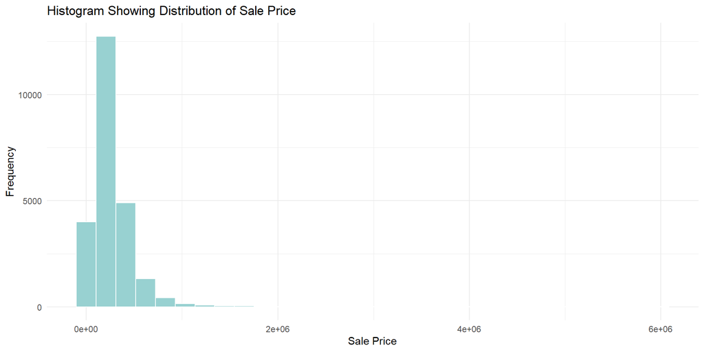

```r
histogram_saleprice <- ggplot(analyzeData, aes(x = sale_price.x)) +
  geom_histogram(fill = "#98d1d1", color = "white", bins = 30) +
  labs(title = "Histogram Showing Distribution of Sale Price", x = "Sale Price", y = "Frequency") +
  theme_minimal()

print(histogram_saleprice)
```

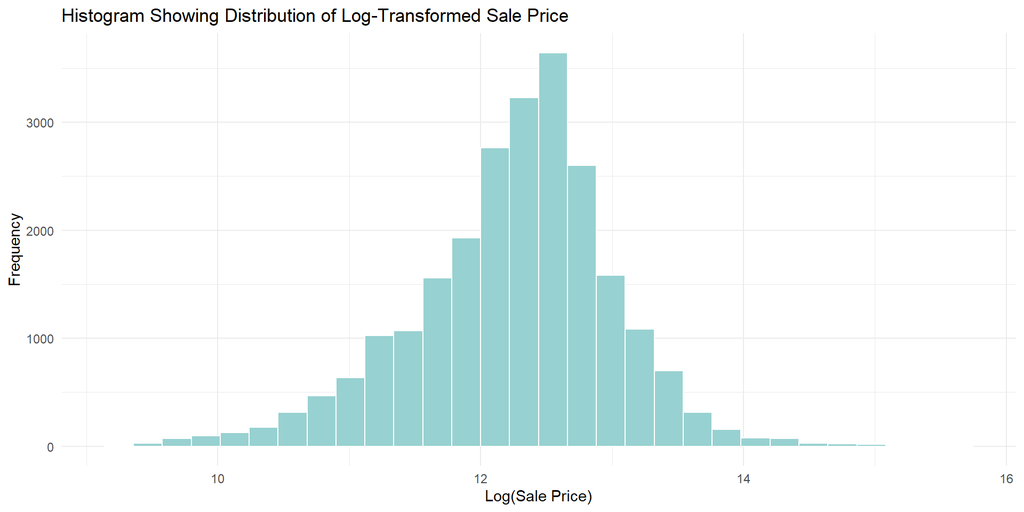

```r
# Log transform the sale_price.x variable
analyzeData$log_sale_price <- log(analyzeData$sale_price.x)

histogram_saleprice_log <- ggplot(analyzeData, aes(x = log_sale_price)) +
  geom_histogram(fill = "#98d1d1", color = "white", bins = 30) +
  labs(title = "Histogram Showing Distribution of Log-Transformed Sale Price", x = "Log(Sale Price)", y = "Frequency") +
  theme_minimal()

print(histogram_saleprice_log)
```

#### Spatial Distribution

We also looked at the spatial distribution of observed home price values across census tracts in Philadelphia to gain insights into the geographical variations in housing affordability, identifying areas of the city where home prices tend to be higher or lower. Dark pink hues on the map signify lower sale prices, while light pink highlights areas with higher sale prices.

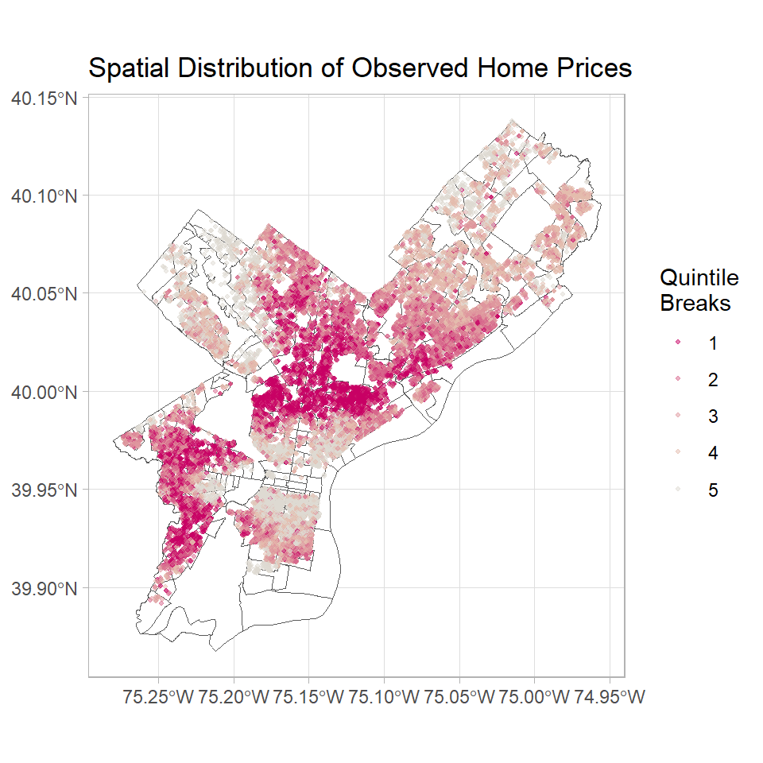

```r
library(sf)
library(ggplot2)
library(viridis)
#library(patchwork)
#library(gridExtra)

City_Limits <- st_read("D:/OneDrive - PennO365/Semester 3/PPA/Midterm/Data/Census_Tracts_2010.geojson")
#City_Limits <- st_read("C:/Users/dmvil/Desktop/PPA/DV PPA midterm/data/City_Limits.geojson")

#PLOT OF PRICES
prices_plot <- ggplot() +
  geom_sf(data = City_Limits, fill = "white") +
  geom_sf(data = Point_data_ACS, aes(colour = q5(price_q)),
          show.legend = "point", size = 0.75, alpha = 0.5) +
  scale_colour_manual(values = rev(palette9), name = "Quintile\nBreaks") +
  labs(title = "Spatial Distribution of Observed Home Prices") +
  theme_light()
print(prices_plot)
```

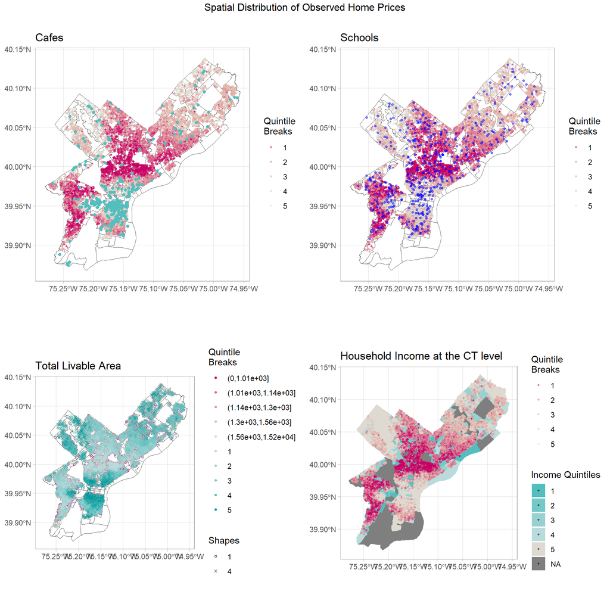

```r
# PLOT OF CAFES
prices_cafes_plot <- ggplot() +
  geom_sf(data = City_Limits, fill = "white") +
  geom_sf(data = Point_data_ACS, aes(colour = q5(price_q)),
          show.legend = "point", size = 0.75, alpha = 0.5) +
  scale_colour_manual(values = rev(palette9), name = "Quintile\nBreaks") +
  geom_sf(data = Cafes, color = "#54bebe", size = 1.5) +
  labs(title = "Cafes")+
  theme_light()
#print(prices_cafes_plot)

# PLOT OF SCHOOLS
prices_schools_plot <- ggplot() +
  geom_sf(data = City_Limits, fill = "white") +
  geom_sf(data = Point_data_ACS, aes(colour = q5(price_q)),
          show.legend = "point", size = 0.75, alpha = 0.5) +
  scale_colour_manual(values = rev(palette9), name = "Quintile\nBreaks") +
  geom_sf(data = Schools, color = "blue", size = 1, alpha=0.5) +
  labs(title = "Schools")+
  theme_light()
#print(prices_schools_plot)

# Plot for Total Livable Area with adjusted color scale by quintiles
area_quintile_breaks <- quantile(studentData_filtered$total_livable_area, probs = seq(0, 1, 0.2), na.rm = TRUE)

palette7 <- c("#54bebe", "#76c8c8", "#98d1d1", "#badbdb", "#dedad2")
#
# livable_area_plot <- ggplot() +
#   geom_sf(data = City_Limits, fill = "white") +
#   geom_sf(data = studentData_filtered, aes(color = cut(total_livable_area, breaks = area_quintile_breaks)),
#           show.legend = "point", size = 1) +
#   scale_color_manual(name = "Quintile Breaks", values = palette7) +
#   labs(title = "Spatial Distribution by total livable area")
# print(livable_area_plot)
#
# # Arrange the plots in a grid
# library(gridExtra)
# grid.arrange(prices_plot, livable_area_plot, ncol = 2)

palette10 <- c("#009999", "#54bebe", "#76c8c8", "#98d1d1", "#badbdb", "#dedad2", "#e4bcad", "#df979e", "#d7658b", "#c80064")

# Plot the map based on quintiles
livable_area_plot <- ggplot() +
  geom_sf(data = City_Limits, fill = "white") +
  geom_sf(data = studentData_filtered, aes(color = cut(total_livable_area, breaks = area_quintile_breaks, values = palette7), shape = "1"),
          show.legend = "point", size = 1) +  # Use shape 1
  #scale_color_manual(name = "Quintile Breaks", values = palette7) +
  geom_sf(data = Point_data_ACS, aes(colour = q5(price_q), shape = "4"), show.legend = "point", size = 1, alpha = 0.5) +  # Use shape 4
  scale_colour_manual(values = rev(palette10), name = "Quintile\nBreaks") +
  labs(title = "Total Livable Area") +
  scale_shape_manual(name = "Shapes", values = c("1" = 1, "4" = 4)) + # Define shape mappings
  theme_light()

#print(livable_area_plot)

# Plot for median household income with adjusted color scale by quintiles by CT

CT_income_quintile_breaks <- quantile(acsTractsPHL.2021$med_HH_Income.2021, probs = seq(0, 1, 0.2), na.rm = TRUE)
# Assign quintiles to the data
acsTractsPHL.2021$quintiles <- cut(acsTractsPHL.2021$med_HH_Income.2021,
                                   breaks = CT_income_quintile_breaks,
                                   include.lowest = TRUE,
                                   labels = FALSE)

# Plot the map based on quintiles
CT_income_quintile_map <- ggplot() +
  geom_sf(data = acsTractsPHL.2021, aes(fill = as.factor(quintiles)), color = "transparent") +
  scale_fill_manual(values = palette7, name = "Income Quintiles") +
  #geom_sf(data = City_Limits, fill = "transparent") +
  geom_sf(data = Point_data_ACS, aes(colour = q5(price_q)),
          show.legend = "point", size = 0.75, alpha = 0.5) +
  scale_colour_manual(values = rev(palette9), name = "Quintile\nBreaks") +
  labs(title = "Household Income at the CT level") +
#print(CT_income_quintile_map) +
  theme_light()

grid.arrange(prices_cafes_plot, prices_schools_plot, livable_area_plot, CT_income_quintile_map,
             ncol = 2,
             top = "Spatial Distribution of Observed Home Prices")
```

### Correlation

Presented below is a correlation matrix that provides insights into the pairwise correlations between different sets of features in our dataset.

In this matrix, darker shades of blue signify a **stronger positive correlation** between the variable in the column and its corresponding variable in the row, while darker shades of pink indicate a **more pronounced negative correlation**.

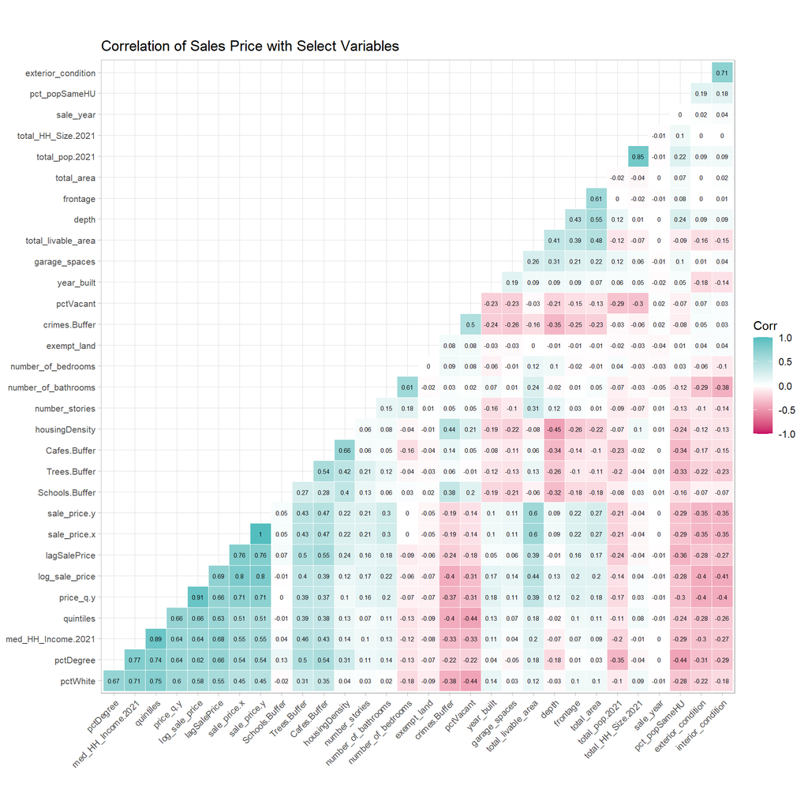

```r
library(ggcorrplot)
numericVars <- select_if(st_drop_geometry(analyzeData), is.numeric) %>%
  na.omit() %>%
  dplyr::select(-objectid, -price_q.x, -fireplaces, -zip_code)

non_numeric_vars <- colnames(analyzeData)[!(colnames(analyzeData) %in% colnames(numericVars))]

if (length(non_numeric_vars) > 0) {
  cat("Non-numeric variables detected and removed:", non_numeric_vars, "\n")
}

# Get the column names with "nn" in them
nn_columns <- grep("nn", names(numericVars), value = TRUE)
numericVars <- numericVars[, !names(numericVars) %in% nn_columns]

str(numericVars)

# Create a correlation matrix

cor_matrix <- cor(numericVars)

# Create the reordered correlation plot
ggcorrplot(
  cor_matrix,
  hc.order = TRUE,
  type = "lower",
  lab = TRUE,
  lab_size = 2,
  method = "square",
  colors = c("#c80064", "white", "#54bebf"),
  ggtheme = ggplot2::theme_light(),
  title = "Correlation of Sales Price with Select Variables",
  outline.color = "white",
  tl.cex = 8
)
```

```r
correlations <- cor(numericVars$log_sale_price, numericVars)
correlations

correlation_data <- data.frame(
  Variable = colnames(correlations),
  Correlation = correlations
)

# Create a kable table
correlation_table <- kable(correlation_data, "html")


#colnames(correlations)
correlations_matrix <- as.matrix(correlations)
correlations_df <- as.data.frame(correlations_matrix)
colnames(correlations_df) <- c("depth", "exempt_land", "exterior_condition", "frontage", "garage_spaces",
                    "interior_condition", "number_of_bathrooms", "number_of_bedrooms", "number_stories",
                    "sale_price.x", "total_area", "total_livable_area", "year_built", "sale_year",
                    "Cafes.Buffer", "Schools.Buffer", "Trees.Buffer", "crimes.Buffer", "total_pop.2021",
                    "med_HH_Income.2021", "total_HH_Size.2021", "pctWhite", "pct_popSameHU", "pctDegree",
                    "pctVacant", "housingDensity", "log_sale_price")  # Add all variable names
correlations_df <- t(correlations_df)

str(correlations_df)
sorted_correlations_df <- correlations_df[order(-correlations_df[, 1]), , drop = FALSE]

############

#corr_tab <- read.csv("correlation_table.csv", header=TRUE)
#corr_tab <- t(corr_tab)


#styling
sorted_correlations_df  %>%
  kbl(caption = "Correlations with Log of sale Prices") %>%
  kable_styling(bootstrap_options = "striped", full_width = T, html_font = "Calibri", font_size = 14) %>%
    scroll_box(width = "750px", height = "500px") %>%
  footnote(general = "Data from OpenDataPhilly and US Census Bureau, ACS 5-year estimates.")

cor.test(numericVars$med_HH_Income.2021, numericVars$log_sale_price, method = "pearson")
```

[output not shown]

##### Correlation of Variables with Log Transformed Sale Price

**Positive Correlations:**

1. **`med_HH_Income.2021`** (0.6353): A higher median household income in the area is positively correlated with higher sale prices.
2. **`pctDegree`** (0.6171): A higher percentage of residents with degrees is positively correlated with higher sale prices.
3. **`pctWhite`** (0.5791): A higher percentage of the population that is White is positively correlated with higher sale prices.
4. **`total_livable_area`** (0.4420): A larger total livable area of a property is positively correlated with higher sale prices.
5. **`Trees.Buffer`** (0.3989): Properties located near more trees or green spaces have a positive correlation with higher sale prices.
6. **`Cafes.Buffer`** (0.3911): Properties near cafes have a positive correlation with higher sale prices.

**Negative Correlations:**

1. **`pctVacant`** (-0.3080): A higher percentage of vacant properties in the area is negatively correlated with sale prices.
2. **`crimes.Buffer`** (-0.3975): A higher proximity to areas with more crimes is negatively correlated with sale prices.
3. **`exterior_condition`** (-0.4039): Poorer exterior property condition is negatively correlated with sale prices.
4. **`interior_condition`** (-0.4064): Poorer interior property condition is negatively correlated with sale prices.

Within this matrix, there are notable correlations that warrant attention. For instance:

The `med_HH_income.2021` median census tract household income, which got the highest correlation coefficient at 0.64, relates to the neighborhood characteristics and spatial structure of the pricing process. Other census tract variables (pctDegree, and pctWhite) had the next two highest coefficients.

The next variable, `total_livable_area` with a coefficient of 0.44, is a physical characteristic of the properties.

The `Trees.Buffer` and `Cafes.Buffer` variables, which was the 5th and 6th highest coefficients in our correlation matrix at 0.40 and 0.39 respectively, are examples of the effect of amenities surrounding properties.

Based on the results of our correlation matrix, the variables that show the most promise for a predictive model are the ones with the largest coefficients, measured in absolute terms. This means that we are also considering variables with the strongest negative correlation to sale prices, such as `interior_condition` and `crimes.Buffer`, which have coefficients of -0.41 and -0.40, respectively.

Based on these results, we examine variables- **`med_HH_Income.2021`**, **`pctDegree`**, **`pctWhite`**, **`total_livable_area`**, **`Cafes.Buffer`**, **`pctVacant`**, **`crimes.Buffer`**, and **`interior_condition`** closely using home price correlation scatterplots.

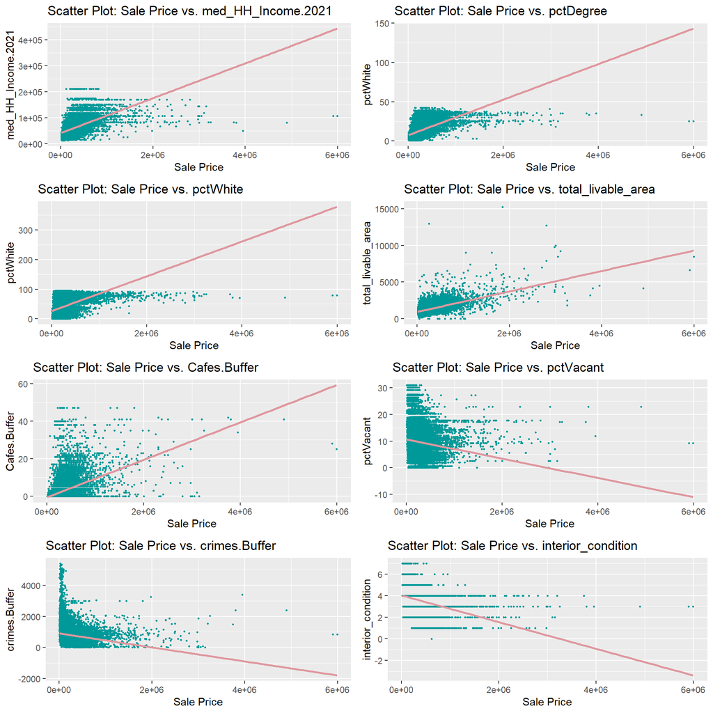

```r
library(grid)
library(gridExtra)
plot1 <- ggplot(numericVars, aes(x = sale_price.x, y = med_HH_Income.2021)) +
  geom_point(size = 0.5, color = "#009999") +
  geom_smooth(method = "lm", se = FALSE, color = "#df979e") +
  labs(x = "Sale Price", y = "med_HH_Income.2021") +
  ggtitle("Scatter Plot: Sale Price vs. med_HH_Income.2021")

plot2 <- ggplot(numericVars, aes(x = sale_price.x, y = pctDegree)) +
  geom_point(size = 0.5, color = "#009999") +
  geom_smooth(method = "lm", se = FALSE, color = "#df979e") +
  labs(x = "Sale Price", y = "pctWhite") +
  ggtitle("Scatter Plot: Sale Price vs. pctDegree")

plot3 <- ggplot(numericVars, aes(x = sale_price.x, y = pctWhite)) +
  geom_point(size = 0.5, color = "#009999") +
  geom_smooth(method = "lm", se = FALSE, color = "#df979e") +
  labs(x = "Sale Price", y = "pctWhite") +
  ggtitle("Scatter Plot: Sale Price vs. pctWhite")

plot4 <- ggplot(numericVars, aes(x = sale_price.x, y = total_livable_area)) +
  geom_point(size = 0.5, color = "#009999") +
  geom_smooth(method = "lm", se = FALSE, color = "#df979e") +
  labs(x = "Sale Price", y = "total_livable_area") +
  ggtitle("Scatter Plot: Sale Price vs. total_livable_area")

plot5 <- ggplot(numericVars, aes(x = sale_price.x, y = Cafes.Buffer)) +
  geom_point(size = 0.5, color = "#009999") +
  geom_smooth(method = "lm", se = FALSE, color = "#df979e") +
  labs(x = "Sale Price", y = "Cafes.Buffer") +
  ggtitle("Scatter Plot: Sale Price vs. Cafes.Buffer")

plot6 <- ggplot(numericVars, aes(x = sale_price.x, y = pctVacant)) +
  geom_point(size = 0.5, color = "#009999") +
  geom_smooth(method = "lm", se = FALSE, color = "#df979e") +
  labs(x = "Sale Price", y = "pctVacant") +
  ggtitle("Scatter Plot: Sale Price vs. pctVacant")

plot7 <- ggplot(numericVars, aes(x = sale_price.x, y = crimes.Buffer)) +
  geom_point(size = 0.5, color = "#009999") +
  geom_smooth(method = "lm", se = FALSE, color = "#df979e") +
  labs(x = "Sale Price", y = "crimes.Buffer") +
  ggtitle("Scatter Plot: Sale Price vs. crimes.Buffer")

plot8 <- ggplot(numericVars, aes(x = sale_price.x, y = interior_condition)) +
  geom_point(size = 0.5, color = "#009999") +
  geom_smooth(method = "lm", se = FALSE, color = "#df979e") +
  labs(x = "Sale Price", y = "interior_condition") +
  ggtitle("Scatter Plot: Sale Price vs. interior_condition")

# Arrange plots in a 2x4 grid
library(gridExtra)
grid.arrange(plot1, plot2, plot3, plot4, plot5, plot6, plot7, plot8, ncol = 2)
```

```r
#dev.off()
```

#### Spatial Lag

Spatial lag is crucial for price predictions as it addresses the spatial dependence inherent in property data. Spatial autocorrelation, where similar values cluster in close proximity, is common in real estate, and failing to consider it can lead to biased parameter estimates and underestimated variability in prices. The inclusion of spatial lag variables captures the influence of neighboring property prices, reflecting local effects and improving prediction accuracy. By accounting for spatial relationships, models become more realistic, providing a better understanding of how prices are distributed across space. The creation of a lagged variable `lagSalePrice` helps incorporate information about nearby property prices into predictive models, enhancing their ability to capture spatial patterns and deliver more accurate predictions for property prices.

```r
# ### KNN for spatial price lag
# create_lagged_variable <- function(data, distance) {
#   coords <- st_coordinates(data$geometry)
#   neighborList <- knn2nb(knearneigh(coords, k = 5))  # k = 5 includes the point itself and its nearest neighbor
#   spatialWeights <- nb2listw(neighborList, style = "W")
#   data$lagSalePrice <- lag.listw(spatialWeights, data$sale_price)
#   return(data)
# }
# Point_data_ACS <- create_lagged_variable(Point_data_ACS, distance = 0.5)
```

## Methodology

We utilized Ordinary Least Squares (OLS) regression as our chosen method for predicting sale prices.

OLS is a widely-used statistical technique for estimating the coefficients of linear regression equations, which help us understand the relationship between one or more independent quantitative variables and a dependent variable.

In our case, we aimed to establish a meaningful correlation between home sale prices and various factors, such as income, crime, and presence of amenities (cafes, schools, trees).

The model itself was constructed using a random sample comprising 70% of the data, which we referred to as the **training dataset.** The remaining 30% of the data served as the **test dataset**, where we evaluated how well the model performed when applied to unseen data.

To assess the model’s effectiveness, we employed various error metrics, which provided insights into the model’s accuracy and precision.

Additionally, we conducted an investigation into the spatial patterns associated with errors and sale prices.

This spatial analysis allowed us to better understand any geographical dependencies and patterns within the dataset, providing valuable insights into the spatial process related to our predictions and errors.

#### OLS Regressions

```r
#colnames(analyzeData)
conflicted::conflicts_prefer(dplyr::filter)
analyzeData$exterior_condition <- as.factor(analyzeData$exterior_condition)
analyzeData$interior_condition <- as.factor(analyzeData$interior_condition)
analyzeData$fireplaces <- as.factor(analyzeData$fireplaces)
analyzeData$garage_spaces <- as.factor(analyzeData$garage_spaces)
analyzeData$redline <- as.factor(analyzeData$redline)

data.features <- analyzeData %>%
  dplyr::filter(toPredict == "MODELLING")

data.features_sf <- analyzeData_sf %>%
  dplyr::filter(toPredict == "MODELLING")

# Split Data
set.seed(123)  # For reproducibility
train_indices <- sample(1:nrow(data.features), nrow(data.features) * 0.7)
train_data <- data.features[train_indices, ]
test_data <- data.features[-train_indices, ]

train_data_sf <- data.features_sf[train_indices, ]
test_data_sf <- data.features_sf[-train_indices, ]


# Check if log_sale_price is numeric
#str(train_data$log_sale_price)

### Kitchen Sink Model
single_level_vars <- sapply(train_data, function(x) length(unique(x)) == 1)
predictor_vars <- names(train_data)[!single_level_vars]
predictor_vars <- predictor_vars[!grepl("^GEOID|^NAME$", predictor_vars)]
kitchensink <- lm(sale_price.x ~ ., data = train_data[, predictor_vars])

#summary(kitchensink)
kitchensink_table <- tab_model(kitchensink, transform = NULL, auto.label = FALSE,
          dv.labels = c("Kitchen Sink Model"),  show.est = TRUE, show.stat = TRUE, string.pred = "Coeffcient",
  string.ci = "Conf. Int (95%)",
  string.p = "P-Value")

# Build the linear regression model
lm_model <- lm(sale_price.x ~ interior_condition +
                 exterior_condition +
                 fireplaces +
                 total_livable_area +
                 number_of_bathrooms +
                 Cafes.Buffer +
                 Trees.Buffer +
                 crimes.Buffer +
                 med_HH_Income.2021 +
                 pctWhite +
                 pctDegree +
                 pctVacant +
                 housingDensity +
                 redline +
                 #garage_spaces +
                 lagSalePrice +
                 Schools.Buffer, data = train_data)

# Summarize the model
model_summary_1 <- summary(lm_model)
#print(model_summary_1)

tab_model(lm_model, transform = NULL, auto.label = FALSE,
          dv.labels = c("Prediction Model"),  show.est = TRUE, show.stat = TRUE, string.pred = "Coeffcient",
  string.ci = "Conf. Int (95%)",
  string.p = "P-Value")
```

|  | Prediction Model |  |  |  |
| --- | --- | --- | --- | --- |
| Coeffcient | Estimates | Conf. Int (95%) | Statistic | P-Value |
| (Intercept) | 4479.38 | -72208.16 – 81166.93 | 0.11 | 0.909 |
| interior_condition1 | -27925.51 | -103003.10 – 47152.08 | -0.73 | 0.466 |
| interior_condition2 | -20183.82 | -97432.01 – 57064.38 | -0.51 | 0.609 |
| interior_condition3 | -44447.62 | -121083.91 – 32188.68 | -1.14 | 0.256 |
| interior_condition4 | -80597.28 | -157470.70 – -3723.86 | -2.06 | **0.040** |
| interior_condition5 | -89817.46 | -167793.26 – -11841.66 | -2.26 | **0.024** |
| interior_condition6 | -73420.27 | -155553.25 – 8712.71 | -1.75 | 0.080 |
| interior_condition7 | -113250.41 | -194886.29 – -31614.54 | -2.72 | **0.007** |
| exterior_condition2 | -72627.93 | -97263.45 – -47992.42 | -5.78 | **<0.001** |
| exterior_condition3 | -69022.88 | -91571.98 – -46473.79 | -6.00 | **<0.001** |
| exterior_condition4 | -83209.26 | -105579.52 – -60839.00 | -7.29 | **<0.001** |
| exterior_condition5 | -100844.50 | -125099.26 – -76589.75 | -8.15 | **<0.001** |
| exterior_condition6 | -122081.61 | -155642.46 – -88520.76 | -7.13 | **<0.001** |
| exterior_condition7 | -107256.85 | -141522.25 – -72991.44 | -6.14 | **<0.001** |
| fireplaces1 | 15243.35 | 3446.54 – 27040.15 | 2.53 | **0.011** |
| fireplaces2 | 69941.96 | 38450.63 – 101433.28 | 4.35 | **<0.001** |
| fireplaces3 | 130616.91 | 85991.56 – 175242.27 | 5.74 | **<0.001** |
| fireplaces4 | 345468.17 | 252703.39 – 438232.95 | 7.30 | **<0.001** |
| fireplaces5 | 556722.12 | 484869.61 – 628574.63 | 15.19 | **<0.001** |
| total_livable_area | 145.31 | 141.12 – 149.50 | 67.98 | **<0.001** |
| number_of_bathrooms | 25680.82 | 22450.67 – 28910.97 | 15.58 | **<0.001** |
| Cafes.Buffer | 6687.48 | 6043.29 – 7331.67 | 20.35 | **<0.001** |
| Trees.Buffer | 1204.14 | 829.96 – 1578.31 | 6.31 | **<0.001** |
| crimes.Buffer | -12.99 | -18.08 – -7.91 | -5.01 | **<0.001** |
| med_HH_Income.2021 | 0.13 | 0.00 – 0.25 | 2.01 | **0.044** |
| pctWhite | 592.18 | 484.94 – 699.41 | 10.82 | **<0.001** |
| pctDegree | -573.40 | -931.29 – -215.52 | -3.14 | **0.002** |
| pctVacant | -467.62 | -892.39 – -42.86 | -2.16 | **0.031** |
| housingDensity | 12607866626793.20 | 9399405212852.61 – 15816328040733.79 | 7.70 | **<0.001** |
| redlineB | 19307.78 | 5157.15 – 33458.40 | 2.67 | **0.007** |
| redlineC | 12226.04 | -2522.30 – 26974.38 | 1.62 | 0.104 |
| redlineD | 10621.35 | -4283.33 – 25526.03 | 1.40 | 0.162 |
| redlineNA | 34797.11 | 19487.32 – 50106.89 | 4.46 | **<0.001** |
| lagSalePrice | 0.10 | 0.10 – 0.10 | 58.51 | **<0.001** |
| Schools.Buffer | -1960.97 | -3107.61 – -814.34 | -3.35 | **0.001** |
| Observations | 16235 |  |  |  |
| R<sup>2</sup> / R<sup>2</sup> adjusted | 0.738 / 0.737 |  |  |  |

```r
test <-
  test_data %>% #create predictions here, compare predictions to the observed
  mutate(Regression = "Baseline Regression",
         sale_price.Predict = predict(lm_model, test_data),
         sale_price.Error = sale_price.Predict - sale_price.x,
         sale_price.AbsError = abs(sale_price.Predict - sale_price.x),
         sale_price.APE = sale_price.AbsError / sale_price.Predict)%>%
  filter(sale_price.x < 5000000)

test_sf <-
  test_data_sf %>% #create predictions here, compare predictions to the observed
  mutate(Regression = "Baseline Regression",
         sale_price.Predict = predict(lm_model, test_data),
         sale_price.Error = sale_price.Predict - sale_price.x,
         sale_price.AbsError = abs(sale_price.Predict - sale_price.x),
         sale_price.APE = sale_price.AbsError / sale_price.Predict)%>%
  filter(sale_price.x < 5000000)
```

Kitchen Sink: We tried a model using all variables to check for statistical significance. Some predictors have significant effects on the response variable (p < 0.05): `fireplaces, number_of_bathrooms, total_livable_area, price_q.x, Cafes.Buffer, Schools.Buffer, Trees.Buffer, crimes.Buffer, total_pop.2021, med_HH_Income.2021, total_HH_Size.2021, pctWhite, pctDegree, housingDensity, lagSalePrice`.

Based on this, and the correlation matrix, we then tried to create the leanest model.

We also tried models with Log(Sale Price) as the dependent variable, but since the regression results were comparable, for the ease of this study, we decided to carry forward with the actual Sale Price as our dependent variable. The Log(Sale Price) model can be found in the Appendix.

**Training Model for Actual Sale Price** *`lm_model`:*

**Model Evaluation:**

- **Adjusted R-squared:** The R-squared value of 0.7372 suggests that the model explains approximately 73.72% of the variance in sale prices.
- **F-statistic:** The F-statistic tests the overall significance of the model, and the extremely low p-value (< 0.00000000000000022) indicates that the model is statistically significant.

The model suggests that features such as interior and exterior condition, amenities like fireplaces, neighborhood characteristics, and socioeconomic factors significantly influence property sale prices. The model has a good fit, as indicated by the high R-squared value, and the individual coefficients provide insights into the impact of each variable on the sale price.

#### Test Set

Mean Absolute Error (MAE) of $67,151.95 signifies the average absolute difference between the predicted sale prices and the actual observed prices. In the context of housing prices, this means that, on average, the model’s predictions deviate by approximately $67,151.95 from the actual sale prices.

```r
R = cor(test$sale_price.x, test$sale_price.Predict, method = "pearson", use = "complete.obs")
R2 = R*R
MAE = mean(test$sale_price.AbsError, na.rm = T)
MAPE = mean(test$sale_price.APE, na.rm = T)

testsum <- as.data.frame(cbind(R2, MAE, MAPE))

colnames(testsum)<-c("R Squared", "MAE", "MAPE")

kable(testsum, caption = "", align = "c") %>%
  kable_classic(full_width = T, html_font = "Helvetica", font_size = 15) %>%
  row_spec(0, bold = T) %>%
  footnote(general = "", fixed_small_size = T, general_title = "")
```

| R Squared | MAE | MAPE |
| --- | --- | --- |
| 0.7307142 | 67151.95 | 0.4006183 |

#### Cross Validations

##### MAE Histogram

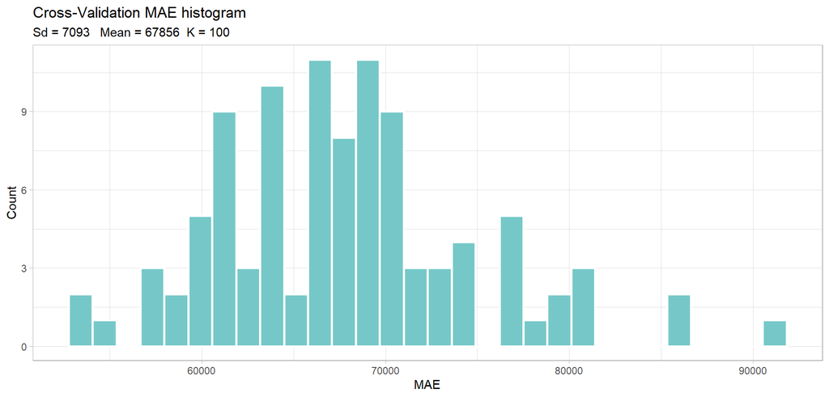

```r
library(caret)
# Remove rows with missing values
#train_data <- na.omit(train_data)

# Define the control for cross-validation (100 folds)
ctrl <- trainControl(method = "cv", number = 100)

lm_model_cv <- train(
  sale_price.x ~ interior_condition +
                 exterior_condition +
                 fireplaces +
                 total_livable_area +
                 number_of_bathrooms +
                 Cafes.Buffer +
                 Trees.Buffer +
                 crimes.Buffer +
                 med_HH_Income.2021 +
                 pctWhite +
                 pctDegree +
                 pctVacant +
                 housingDensity +
                 redline +
                 garage_spaces +
                 lagSalePrice +
                 Schools.Buffer, data = train_data,
  method = "lm",
  trControl = ctrl, na.action = na.pass
)

# Access cross-validation results
cv_results <- lm_model_cv$results
#lm_model_cv$resample[1:5,]

library(data.table)
MAE.cv = data.table(MAE.cv= lm_model_cv$resample[,3])
MAE.sd <- as.character(round(sd(lm_model_cv$resample[,3])))
MAE.mean <- as.character(round(mean(lm_model_cv$resample[,3])))

caption <- paste("Sd =",MAE.sd, "  Mean =",MAE.mean, " K = 100")

ggplot(MAE.cv, aes(x = MAE.cv))+
  geom_histogram(fill= palette9[2], color = "white", size = 1, xlim=c(20,50))+
  labs(title = "Cross-Validation MAE histogram",
       subtitle = caption,
       x="MAE",
       y="Count",
       caption = "")  +
  theme_light()
```

##### Plot predicted prices vs. observed prices

In the “predicted vs observed price” graph most points closely follow the fitted line, it demonstrates that the model is doing a good job in predicting prices.

This is an indication of the model’s accuracy and reliability in predicting real prices.

```r
# ## Add new columns to studentData_challenge
# studentData_challenge_knn <- st_read("D:/OneDrive - PennO365/Semester 3/PPA/Midterm/Data/Point_data_challenge_allKNNs.geojson")
#
# #studentData_challenge <- studentData_filtered %>% filter(sale_price <= 100)
#
# studentData_challenge_join <- st_join(studentData_challenge, studentData_challenge_knn)
# studentData_challenge_join <- studentData_challenge_join %>%
#   rename(objectid = objectid.x) %>%
#   dplyr::select(-objectid.y)
# joined_data_challenge <- st_join(studentData_challenge_join, acsTractsPHL.2021, join = st_intersects)
#
# joined_data_challenge <- st_join(joined_data_challenge, Redline, join = st_within)
# joined_data_challenge <- joined_data_challenge  %>%
#   select(-area_id, -city_id, -fill, -label, -name, -category_id, -sheets, -area, -bounds, -residential, -commercial, -industrial, -label_coords) %>%
#   rename(redline = grade)
#
# joined_data_challenge$crimes.Buffer <- NA
# joined_data_challenge$Schools.Buffer <- NA
# joined_data_challenge$Trees.Buffer <- NA
# joined_data_challenge$Cafes.Buffer <- NA
# joined_data_challenge$price_q <- NA
#
# ### Add missing .Buffers
#
# ## Make analyzeData sf
# analyzeData_sf <- analyzeData_sf %>%
#   select(-sale_price.y, -price_q.y, -lagSalePrice, -avg_crime_nn, -objectid.y) %>%
#   rename(
#     price_q = price_q.x, sale_price = sale_price.x, objectid = objectid.x,
#          crimes_nn1 = crime_nn1, crimes_nn2 = crime_nn2, crimes_nn3 = crime_nn3, crimes_nn4 = crime_nn4, crimes_nn5 = crime_nn5,
#          trees_nn1 = tree_nn1, trees_nn2 = tree_nn2, trees_nn3 = tree_nn3, trees_nn4 = tree_nn4, trees_nn5 = tree_nn5,)
#
# ## Check columns
# colnames(joined_data_challenge)
# colnames(analyzeData_sf)
# desired_order <- c(
#   "cafe_nn1", "cafe_nn2", "cafe_nn3", "cafe_nn4", "cafe_nn5", "Cafes.Buffer",
#   "crimes.Buffer", "crimes_nn1", "crimes_nn2", "crimes_nn3", "crimes_nn4", "crimes_nn5",
#   "depth", "exempt_land", "exterior_condition", "fireplaces", "frontage", "garage_spaces",
#   "GEOID", "geometry", "housingDensity", "interior_condition", "med_HH_Income.2021",
#   "NAME", "number_of_bathrooms", "number_of_bedrooms", "number_stories", "objectid",
#   "pct_popSameHU", "pctDegree", "pctVacant", "pctWhite", "price_q", "quintiles", "redline",
#   "sale_price", "sale_year", "school_nn1", "school_nn2", "school_nn3", "school_nn4", "school_nn5",
#   "Schools.Buffer", "toPredict", "total_area", "total_HH_Size.2021", "total_livable_area",
#   "total_pop.2021", "Trees.Buffer", "trees_nn1", "trees_nn2", "trees_nn3", "trees_nn4",
#   "trees_nn5", "year_built", "zip_code"
# )
#
# joined_data_challenge <- joined_data_challenge %>%
#   select(desired_order)
#
# analyzeData_sf <- analyzeData_sf %>%
#   select(desired_order)
#
#  studentdata.all <- rbind(joined_data_challenge, analyzeData_sf)

 #st_write(studentdata.all, "D:/OneDrive - PennO365/Semester 3/PPA/Midterm/Data/studentdata.all.geojson", driver = "GeoJSON")

studentdata.all <- st_read("D:/OneDrive - PennO365/Semester 3/PPA/Midterm/Data/studentdata.all.geojson")
```

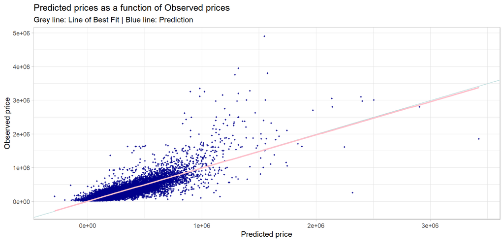

```r
 #colnames(studentdata.all)

### KNN for spatial price lag
# create_lagged_variable <- function(data, distance) {
#   coords <- st_coordinates(data$geometry)
#   neighborList <- knn2nb(knearneigh(coords, k = 5))  # k = 5 includes the point itself and its nearest neighbor
#   spatialWeights <- nb2listw(neighborList, style = "W")
#   data$lagSalePrice <- lag.listw(spatialWeights, data$sale_price)
#   return(data)
# }
# studentdata.all <- create_lagged_variable(studentdata.all, distance = 0.5)

####
model.studentdata.all <-
  lm(sale_price ~ ., data = as.data.frame(studentdata.all) %>%
                             dplyr::select(sale_price,
                                           interior_condition,
                                           exterior_condition,
                                           fireplaces,
                                           total_livable_area,
                                           number_of_bathrooms,
                                           Cafes.Buffer,
                                           Trees.Buffer,
                                           crimes.Buffer,
                                           med_HH_Income.2021,
                                           pctWhite,
                                           pctDegree,
                                           pctVacant,
                                           housingDensity,
                                           redline,
                                           garage_spaces,
                                           #lagSalePrice,
                                           Schools.Buffer))

studentdata.all <-
  studentdata.all %>%
  mutate(Regression = "Baseline Regression",
         sale_price.Predict = predict(model.studentdata.all, studentdata.all),
         sale_price.Error = sale_price.Predict - sale_price,
         sale_price.AbsError = abs(sale_price.Predict - sale_price),
         sale_price.APE = sale_price.AbsError / sale_price.Predict)%>%
  filter(sale_price < 5000000)

ggplot(studentdata.all, aes(x = sale_price.Predict, y = sale_price)) +
  geom_point(size = 0.8, alpha = 0.8, color = "darkblue") +
  geom_abline(color = palette9[4]) +
  geom_smooth(method = "lm", se = FALSE, colour = "pink", size = 1) +
  labs(title = "Predicted prices as a function of Observed prices",
       subtitle = "Grey line: Line of Best Fit | Blue line: Prediction",
       x = "Predicted price",
       y = "Observed price",
       caption = "") +
  theme_light()
```

##### Map of Residuals with Moran’s I

The expectation (E) is approximately -0.0002103. If there were no spatial patterns in the data, we would expect the Moran I statistic to be close to this value.

The variance (Var) is approximately 0.00005608 which suggests that the Moran I statistic is relatively consistent, with low variance.

```r
# geometry_data <- studentData[, c("objectid", "geometry")]
# test <- merge(test, geometry_data, by = "objectid", all.x = TRUE)
# write.csv(test, "D:/OneDrive - PennO365/Semester 3/PPA/Midterm/Data/test.csv")
test <- st_read("D:/OneDrive - PennO365/Semester 3/PPA/Midterm/Data/test.json")
```

```
## replacing null geometries with empty geometries
## Simple feature collection with 8558 features and 68 fields (with 1424 geometries empty)
## Geometry type: POINT
## Dimension:     XY
## Bounding box:  xmin: -75.2733 ymin: 39.89522 xmax: -74.96345 ymax: 40.13646
## Geodetic CRS:  WGS 84
```

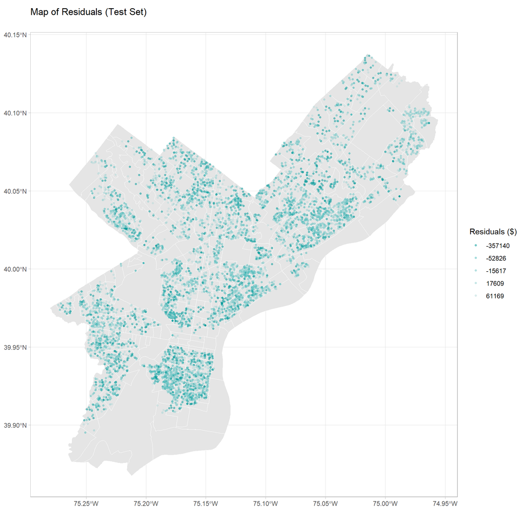

```r
test$sale_price.Error <- as.numeric(test$sale_pri_2)


ggplot() +
  geom_sf(data = City_Limits, color = "white", size = 0.3) +
  geom_sf(data = test, aes(colour = q5(sale_price.Error)), alpha = 0.5, size = 1, show.legend = "point")+
  labs(title = "Map of Residuals (Test Set)",
       subtitle = "",
       caption = '') +
  scale_colour_manual(values = palette10,
                      labels=round(as.numeric(qBr(test,"sale_price.Error"))),
                      name="Residuals ($)",
                      na.translate=FALSE)  +
  theme_light()
```

##### Spatial Auto-correlation

```r
coords <- st_coordinates(Point_data_ACS)
neighborList <- knn2nb(knearneigh(coords, 5))
spatialWeights <- nb2listw(neighborList, style="W")
analyzeData_sf$lagPrice <- lag.listw(spatialWeights, analyzeData_sf$sale_price)

coords.test <- st_coordinates(test_sf)
neighborList.test <- knn2nb(knearneigh(coords.test, 5))
spatialWeights.test <- nb2listw(neighborList.test, style="W")
test$lagPrice <- lag.listw(spatialWeights.test, test$sale_price, NAOK = TRUE)


#imputing mean values!
missing_values <- which(is.na(test$sale_price.Error))
test$sale_price.Error[missing_values] <- mean(test$sale_price.Error, na.rm = TRUE)

moranTest <- moran.mc(test$sale_price.Error, spatialWeights.test, nsim = 999)

#saveRDS(moranTest, file = "moranTest.RDS")

morans-i <- ggplot(as.data.frame(moranTest$res[c(1:999)]), aes(moranTest$res[c(1:999)])) +
  geom_histogram(binwidth = 0.01) +
  geom_vline(aes(xintercept = moranTest$statistic), colour = "#FA7800",size=1) +
  scale_x_continuous(limits = c(-1, 1)) +
  labs(title="Observed and permuted Moran's I",
       subtitle= "Observed Moran's I in orange",
       x="Moran's I",
       y="Count") +
  plotTheme()

SL1 <- ggplot(test, aes(x = lagSalePri, y = sale_price))+
  geom_point(size =0.8, alpha = 0.8, color = palette10[3])+
  geom_abline(color = palette10[5])+
  geom_smooth(method = "lm", se = FALSE, colour = palette10[1], size = 1)+
  labs(title = "Price vs Spatial Lag Price",
       subtitle = "Grey line : Perfect     Blue line : Average",
       x="Spatial Lag Price",
       y="Observed price",
       caption = " ") +
  plotTheme()


SL2 <- ggplot(test, aes(x = lagPriceError, y = sale_price.Error))+
  geom_point(size =0.8, alpha = 0.8, color = palette10[3])+
  geom_abline(color = palette10[5])+
  geom_smooth(method = "lm", se = FALSE, colour = palette10[1], size = 1)+
  labs(title = "Price Error vs Spatial Lag Price Error",
       subtitle = "Grey line : Perfect     Blue line : Average",
       x="Spatial Lag Error",
       y="Error",
       caption = "") +
  plotTheme()

price-spatial <- grid.arrange(SL1, SL2, ncol=2)
```

[output not shown]

##### Map of Predicted Values

The following maps visualizes all the sale price values across Philadelphia. The map on the right has predicted values compared to the map on the left with observed values. When looking at these two visualizations, it appears like the prediction somewhat matches that of the observed values–at least in terms of clustering of certain values in particular neighbourhoods.

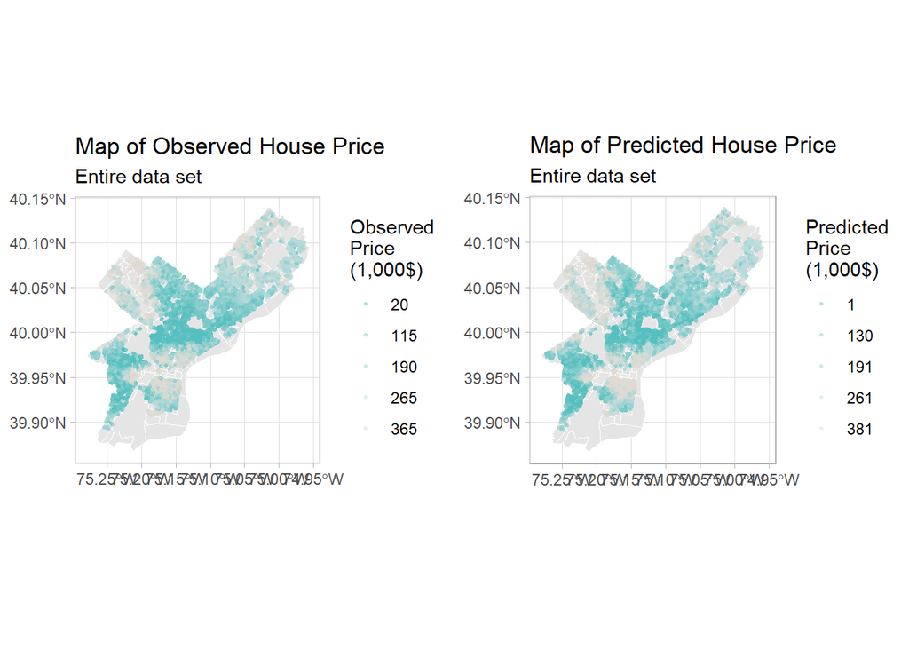

```r
# Remove observations with missing 'depth'
studentdata.all <- studentdata.all[!is.na(studentdata.all$depth), ]

PP <- ggplot() +
  geom_sf(data = City_Limits, color = "white", size = 0.3) +
  geom_sf(data = studentdata.all, aes(colour = q5(sale_price.Predict)), alpha = 0.4, size = 0.5, show.legend = "point")+
  labs(title = "Map of Predicted House Price",
       subtitle = "Entire data set",
       caption = '')+
  scale_colour_manual(values = palette7,
                      labels=round(as.numeric(qBr(studentdata.all,"sale_price.Predict"))/1000),
                      name="Predicted\nPrice\n(1,000$)",
                      na.translate=FALSE)+
  theme_light()

OP <- ggplot() +
  geom_sf(data = City_Limits, color = "white", size = 0.3) +
  geom_sf(data = studentdata.all, aes(colour = q5(sale_price)), alpha = 0.4, size = 0.5, show.legend = "point")+
  labs(title = "Map of Observed House Price",
       subtitle = "Entire data set",
       caption = '')+
  scale_colour_manual(values = palette7,
                      labels=round(as.numeric(qBr(studentdata.all,"sale_price"))/1000),
                      name="Observed\nPrice\n(1,000$)",
                      na.translate=FALSE)+
  theme_light()

grid.arrange(OP, PP, ncol = 2)
```

##### Map of MAPE by Census Tract

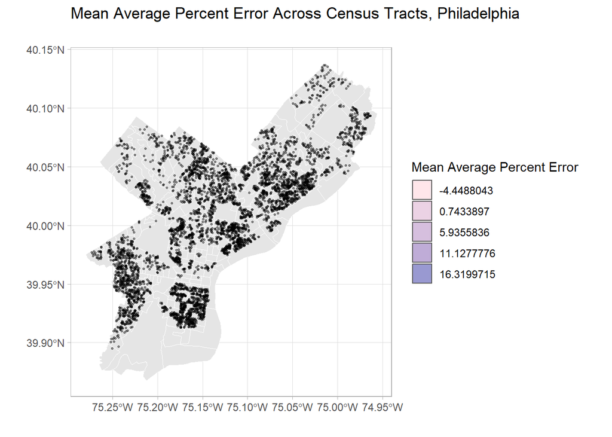

```r
test.MAPE <- test_sf %>%
  group_by(NAME) %>%
  summarise(meanMAPE = mean(sale_price.APE), meanPrice = mean(sale_price.x))

test.MAPE <- test.MAPE[is.finite(test.MAPE$meanMAPE), ]

ggplot() +
  geom_sf(data = City_Limits, color = "white", size = 0.3) +
  geom_sf(data = test.MAPE, aes(fill = meanMAPE), alpha = 0.4, size = 0.5)+
  scale_fill_gradient(low = "pink", high = "darkblue", guide = "legend",
                      name = "Mean Average Percent Error",
                      breaks = seq(min(test.MAPE$meanMAPE), max(test.MAPE$meanMAPE), length.out = 5)) +
  labs(title = "Mean Average Percent Error Across Census Tracts, Philadelphia",
       subtitle = "",
       caption = "") +
  theme_light()
```

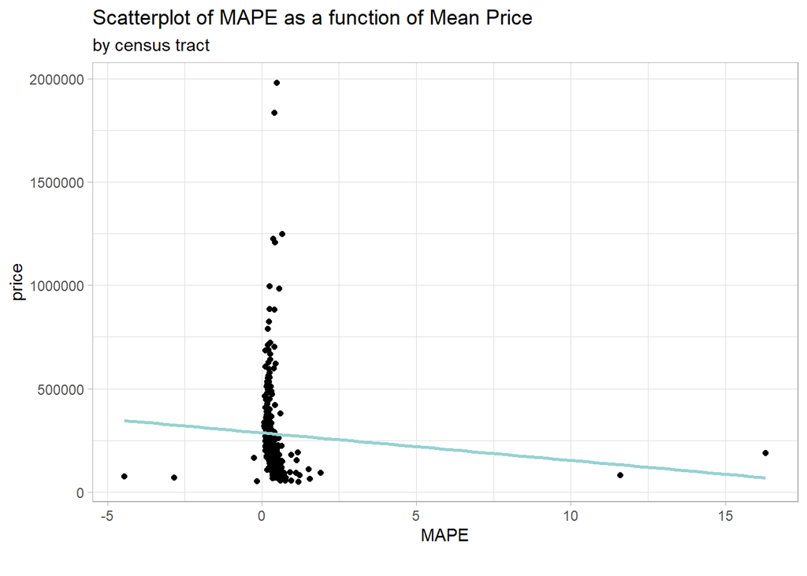

```r
ggplot(test.MAPE , aes(x = meanMAPE, y = meanPrice))+
  geom_point()+
  geom_smooth(method = "lm", se = FALSE, colour = palette10[4], size = 1)+
  labs(title = "Scatterplot of MAPE as a function of Mean Price",
       subtitle = "by census tract",
       x="MAPE",
       y="price",
       caption = "") +
  theme(axis.title.x = element_text(size = 10),
        axis.title.y = element_text(size = 10),
        text = element_text(size = 10),
        panel.background = element_rect(fill = "white"),
        plot.title = element_text(hjust = 0.5),
        plot.subtitle = element_text(hjust = 0.5, face ="italic"),
        plot.caption=element_text(hjust = 0.5)
        )+
  theme_light()
```

##### Split by Census Groups

We partitioned our study area into two distinct groups based on racial and income considerations, as depicted in the following visualizations. In the race context map (CT1), shades of blue indicate areas with a majority of non-white residents, while pink shades signify areas with a majority of white residents. In the income context map (CT2), blues represent neighborhoods with high income, and pink represent those with low income.

Upon juxtaposing these maps with the predicted house prices, it is evident that the model effectively predicts values across varying racial and income contexts. The model’s generalizability is highlighted by its accurate predictions for both relatively high and low house values. For example, in regions along the western edge of the city characterized by low poverty and high income (indicated by blue shades), the model predicts notably higher house values. Conversely, in the southwestern part of the city, where there is a prevalence of high poverty and low income (indicated by pink shades), the model predicts lower house prices. This observation is contingent upon the assumption that areas with low poverty and high income correspond to higher observed house prices.

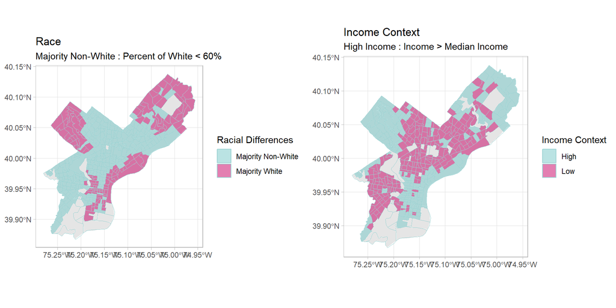

```r
nhoods.split <- acsTractsPHL.2021 %>%
  mutate(raceContext = ifelse(pctWhite > 60, "Majority White", "Majority Non-White"),
         incomeContext = ifelse(med_HH_Income.2021 > mean(med_HH_Income.2021,na.rm = T), "High", "Low"))

CT1 <- ggplot() +
  geom_sf(data = City_Limits, color = "white", size = 0.3) +
  geom_sf(data = nhoods.split, aes(fill = raceContext), color = palette9[3], size = 1, alpha = 0.5) +  scale_fill_manual(values = c(palette9[2],palette9[9]),
                    name = "Racial Differences",
                    na.translate=FALSE) +
  labs(title = "Race",
       subtitle = "Majority Non-White : Percent of White < 60%",
       caption = '') +
  theme_light()

CT2 <- ggplot() +
  geom_sf(data = City_Limits, color = "white", size = 0.3) +
  geom_sf(data = nhoods.split, aes(fill = incomeContext), color = palette9[3], size = 1, alpha = 0.5) +
  scale_fill_manual(values = c(palette9[2],palette9[9]),
                    name = "Income Context",
                    na.translate=FALSE) +
  labs(title = "Income Context",
       subtitle = "High Income : Income > Median Income",
       caption = '') +
  theme_light()

grid.arrange(CT1, CT2, ncol = 2)
```

## Discussion

The results of the analysis shows that the model developed for predicting property sale prices in the context of the Zillow use case is reasonably effective, but there are some important considerations to take into account. The model’s effectiveness can be assessed from several angles.

Some of the more interesting variables in the model include `"interior_condition," "Cafes.Buffer," "Trees.Buffer," "crimes.Buffer," "med_HH_Income.2021," "pctWhite," "pctDegree,"` and `"pctVacant."` These variables were found to have statistically significant effects on sale prices. The spatial analysis revealed that properties with similar sale prices tend to be clustered together, as indicated by the positive Moran’s I statistic. The presence of significant spatial autocorrelation implies that sale prices are not randomly distributed but tend to be geographically clustered.

The model seems to predict particularly well in areas where property prices exhibit spatial clustering, which aligns with the spatial autocorrelation findings. It may perform poorly in regions with highly heterogeneous property markets or where other unaccounted-for factors play a significant role. The reasons for variations in predictive accuracy may include factors not considered in the model, temporal changes in property market dynamics, or the influence of neighborhood-specific variables not accounted for. To improve the model’s performance, further exploration of additional relevant variables and refinement of the modeling approach may be necessary.

## Conclusion

The model developed for predicting property sale prices in the context of the Zillow use case provides valuable insights into the factors influencing property values. While the model exhibits **moderate effectiveness** in explaining variations in sale prices, there are areas for consideration before recommending its implementation to Zillow.

The model’s strengths lie in its ability to capture significant predictors such as property condition, neighborhood features, income, and demographics, which collectively explain a substantial portion of the variance in sale prices. The presence of spatial clustering, as indicated by Moran’s I, aligns with the geographic nature of real estate markets. This provides valuable information for Zillow to understand localized property value dynamics.

However, the model has room for improvement. The Mean Absolute Error (MAE) of approximately $67,000 suggests that there is still **notable room for error in the predictions**. The model may perform better in areas with spatial clustering of sale prices but could be less accurate in heterogeneous markets. To enhance the model’s performance, **Zillow should consider the inclusion of additional relevant variables, exploration of more advanced modeling techniques, and regular updates to account for changing real estate market dynamics.**

To further enhance the model:

**Additional Variables:** Explore additional relevant variables that may contribute to price variation. **Temporal Adjustments:** Incorporate temporal adjustments to account for changes in market dynamics. **Geographical Considerations:** Address variations in predictive accuracy in different geographical contexts.

Ultimately**, we would recommend the model to Zillow as a valuable tool for understanding property value determinants and for guiding pricing strategies.** However, it should be seen as **a starting point rather than a definitive pricing tool.** The model, when continually refined and updated, can become an essential component in Zillow’s real estate valuation toolkit.

## Appendix A

**Kitchen Sink Model for Actual Sale Price** *`kitchensink`:*

```r
kitchensink_table
```

|  | Kitchen Sink Model |  |  |  |
| --- | --- | --- | --- | --- |
| Coeffcient | Estimates | Conf. Int (95%) | Statistic | P-Value |
| (Intercept) | -0.00 | -0.00 – 0.00 | -1.33 | 0.184 |
| objectid | 0.00 | -0.00 – 0.00 | 1.23 | 0.219 |
| depth | 0.00 | 0.00 – 0.00 | 18.60 | **<0.001** |
| exempt_land | 0.00 | -0.00 – 0.00 | 1.04 | 0.299 |
| exterior_condition2 | 0.00 | 0.00 – 0.00 | 5.60 | **<0.001** |
| exterior_condition3 | 0.00 | 0.00 – 0.00 | 5.87 | **<0.001** |
| exterior_condition4 | 0.00 | 0.00 – 0.00 | 6.93 | **<0.001** |
| exterior_condition5 | 0.00 | 0.00 – 0.00 | 6.76 | **<0.001** |
| exterior_condition6 | 0.00 | 0.00 – 0.00 | 6.20 | **<0.001** |
| exterior_condition7 | 0.00 | 0.00 – 0.00 | 3.29 | **0.001** |
| fireplaces1 | -0.00 | -0.00 – -0.00 | -3.02 | **0.003** |
| fireplaces2 | -0.00 | -0.00 – -0.00 | -9.23 | **<0.001** |
| fireplaces3 | -0.00 | -0.00 – -0.00 | -10.99 | **<0.001** |
| fireplaces4 | -0.00 | -0.00 – -0.00 | -11.52 | **<0.001** |
| fireplaces5 | -0.00 | -0.00 – -0.00 | -22.32 | **<0.001** |
| frontage | 0.00 | 0.00 – 0.00 | 5.47 | **<0.001** |
| garage_spaces1 | -0.00 | -0.00 – -0.00 | -2.74 | **0.006** |
| garage_spaces2 | -0.00 | -0.00 – -0.00 | -17.48 | **<0.001** |
| garage_spaces3 | -0.00 | -0.00 – -0.00 | -4.91 | **<0.001** |
| garage_spaces4 | -0.00 | -0.00 – -0.00 | -4.31 | **<0.001** |
| garage_spaces6 | 0.00 | -0.00 – 0.00 | 0.89 | 0.375 |
| garage_spaces72 | 0.00 | 0.00 – 0.00 | 11.66 | **<0.001** |
| interior_condition1 | 0.00 | -0.00 – 0.00 | 0.23 | 0.820 |
| interior_condition2 | 0.00 | -0.00 – 0.00 | 0.48 | 0.632 |
| interior_condition3 | 0.00 | -0.00 – 0.00 | 0.20 | 0.844 |
| interior_condition4 | 0.00 | -0.00 – 0.00 | 0.43 | 0.669 |
| interior_condition5 | 0.00 | -0.00 – 0.00 | 0.50 | 0.616 |
| interior_condition6 | 0.00 | -0.00 – 0.00 | 0.43 | 0.664 |
| interior_condition7 | 0.00 | -0.00 – 0.00 | 0.62 | 0.532 |

[output cut: 51 more lines]

## Appendix B

**Training Model for Log(Sale Price)** *`lm_model_log`:*

**F-statistic:** The extremely low p-value (< 0.00000000000000022) suggests that the model is statistically significant and fits the data well.

```r
lm_model_log <- lm(log_sale_price ~ interior_condition +
                 exterior_condition +
                 fireplaces +
                 total_livable_area +
                 number_of_bathrooms +
                 Cafes.Buffer +
                 Trees.Buffer +
                 crimes.Buffer +
                 med_HH_Income.2021 +
                 pctWhite +
                 pctDegree +
                 pctVacant +
                 housingDensity +
                 redline +
                 lagSalePrice +
                 Schools.Buffer, data = train_data)

#Summarize the model
model_summary_2 <- summary(lm_model_log)
print(model_summary_2)
```

`Call:`

`lm(formula = log_sale_price ~ interior_condition + exterior_condition +`

`fireplaces + total_livable_area + number_of_bathrooms + Cafes.Buffer +`

`Trees.Buffer + crimes.Buffer + med_HH_Income.2021 + pctWhite +`

`pctDegree + pctVacant + housingDensity + redline + lagSalePrice +`

`Schools.Buffer, data = train_data)`

`Residuals:`

`Min 1Q Median 3Q Max`

`-2.83292 -0.19200 0.05592 0.25127 2.37675`

`Coefficients:`

`Estimate Std. Error t value Pr(>|t|)`

`(Intercept) 12.115258936408 0.038287413885 316.429 < 0.0000000000000002 ***`

`exterior_condition -0.064662464989 0.005869621653 -11.016 < 0.0000000000000002 ***`

`fireplaces -0.054870561965 0.012845952933 -4.271 0.000019533167857777 ***`

`total_livable_area 0.000307558529 0.000007159259 42.960 < 0.0000000000000002 ***`

`number_of_bathrooms 0.026359141903 0.005553036174 4.747 0.000002084267947787 ***`

`Cafes.Buffer 0.009116825855 0.001120610874 8.136 0.000000000000000439 ***`

`Trees.Buffer 0.006070901812 0.000649126001 9.352 < 0.0000000000000002 ***`

`crimes.Buffer -0.000269796473 0.000008848157 -30.492 < 0.0000000000000002 ***`

`med_HH_Income.2021 0.000001295700 0.000000215534 6.012 0.000000001876632936 ***`

`pctWhite 0.003596629629 0.000186005856 19.336 < 0.0000000000000002 ***`

`pctDegree 0.007876191987 0.000620787893 12.687 < 0.0000000000000002 ***`

`pctVacant -0.004212781847 0.000735930589 -5.724 0.000000010561808003 ***`

`housingDensity 53785232.981349572539 5570924.610482434742 9.655 < 0.0000000000000002 ***`

`redlineB 0.119807981915 0.024644832969 4.861 0.000001176596770228 ***`

`redlineC -0.072527544526 0.025669728311 -2.825 0.004728 **`

`redlineD -0.026800672221 0.025896942326 -1.035 0.300732`

`redlineNA 0.102264233118 0.026646172416 3.838 0.000125 ***`

`lagSalePrice 0.000000173530 0.000000005756 30.146 < 0.0000000000000002 ***`

`Schools.Buffer 0.004216073402 0.001997668897 2.110 0.034831 *`

`---`

`Signif. codes: 0 ‘***’ 0.001 ‘**’ 0.01 ‘*’ 0.05 ‘.’ 0.1 ‘ ’ 1`

`Residual standard error: 0.4222 on 16215 degrees of freedom`

`(411 observations deleted due to missingness)`

`Multiple R-squared: 0.687, Adjusted R-squared: 0.6866`

`F-statistic: 1873 on 19 and 16215 DF, p-value: < 0.00000000000000022`